# Trust but Verify: AI Models for Coding Political Content in Social Media

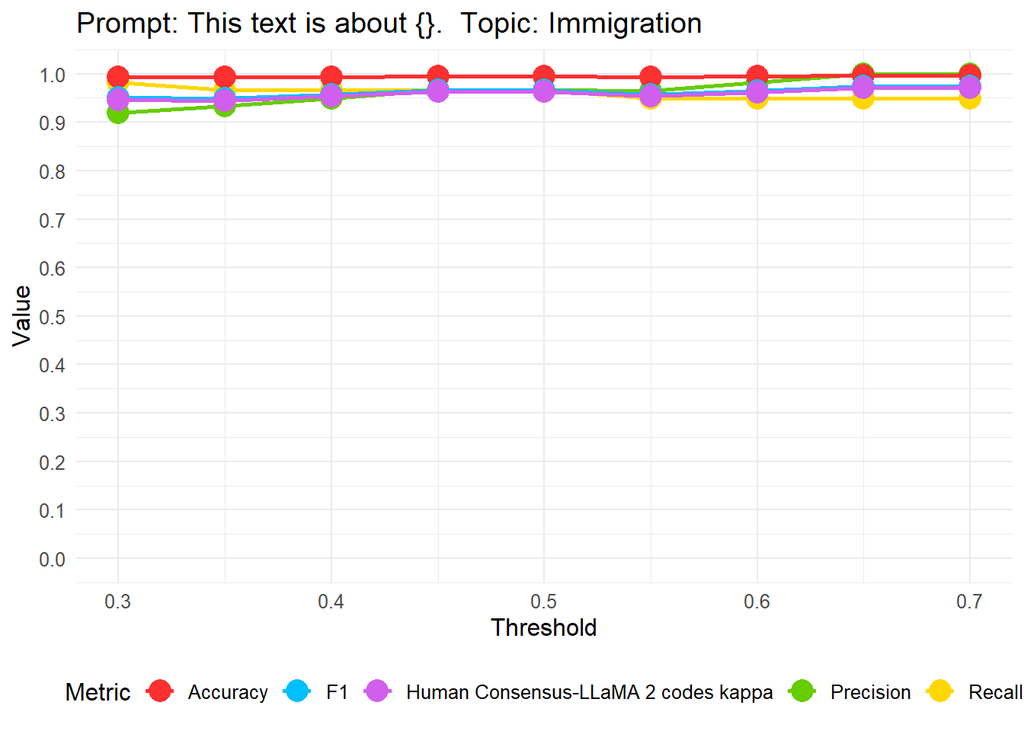

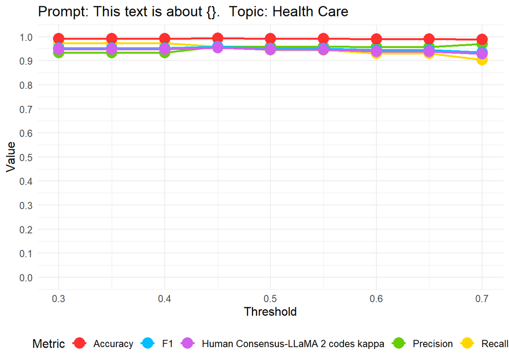

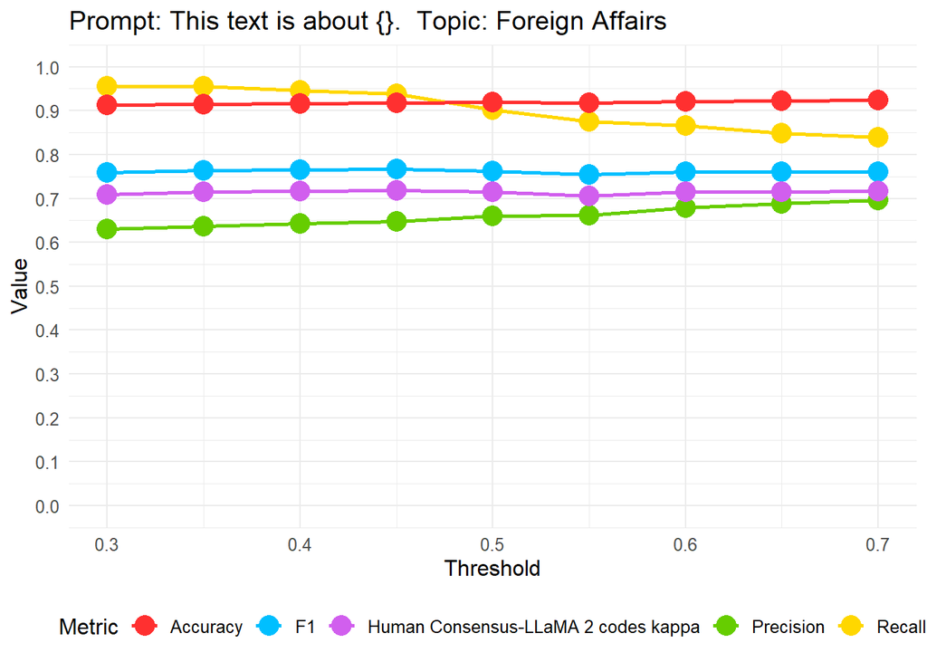

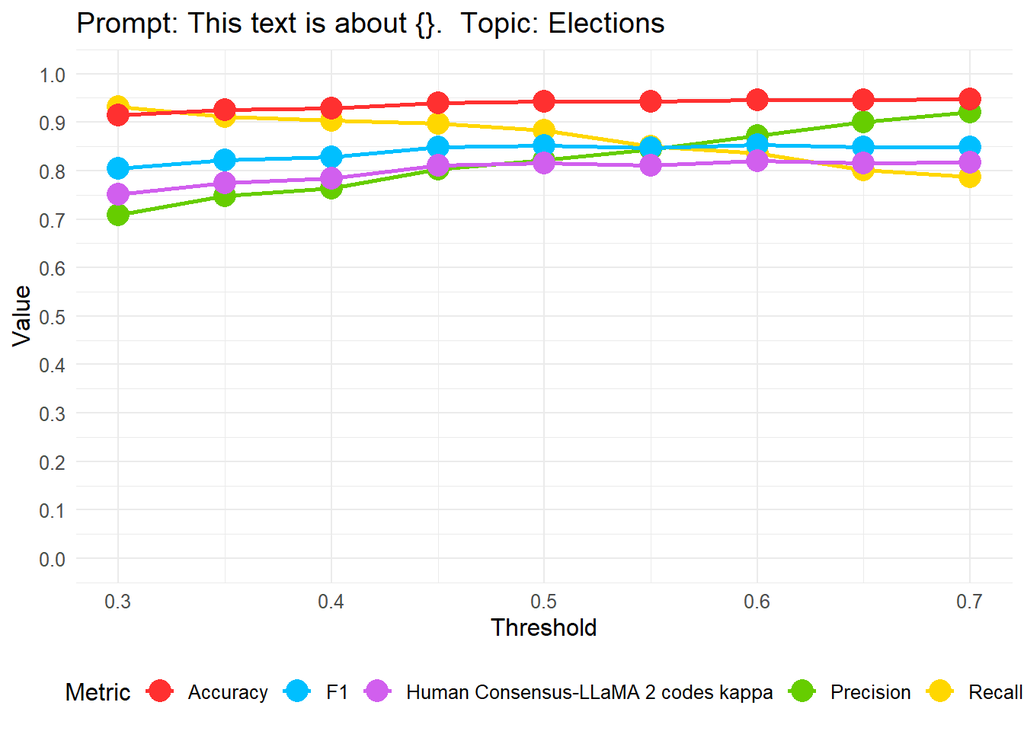

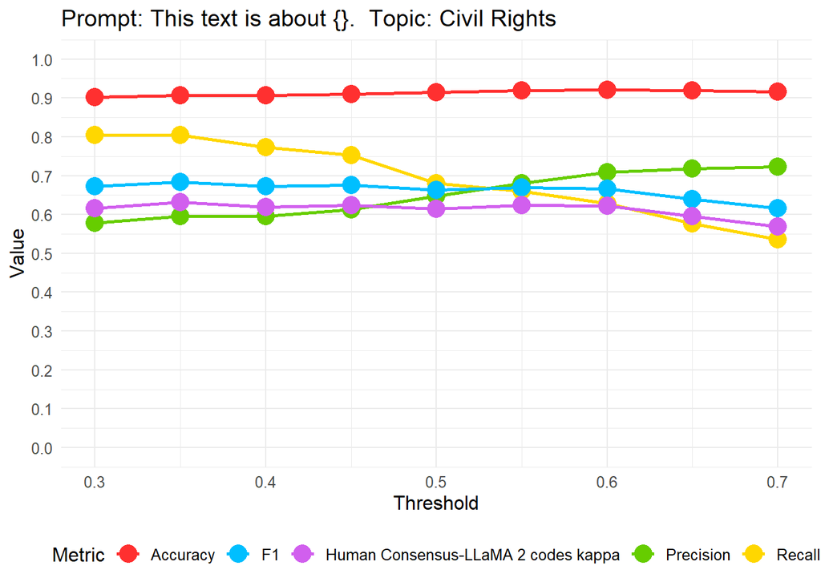

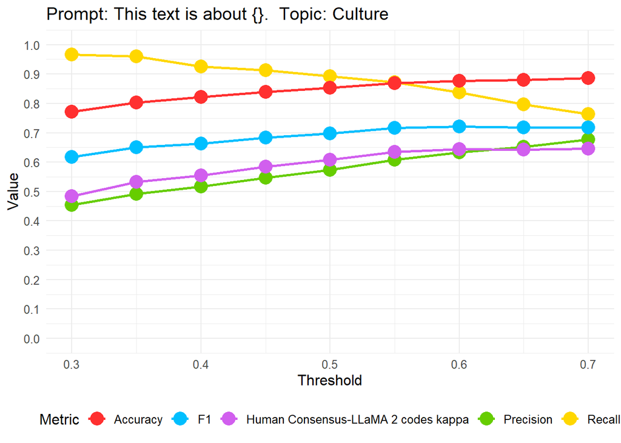

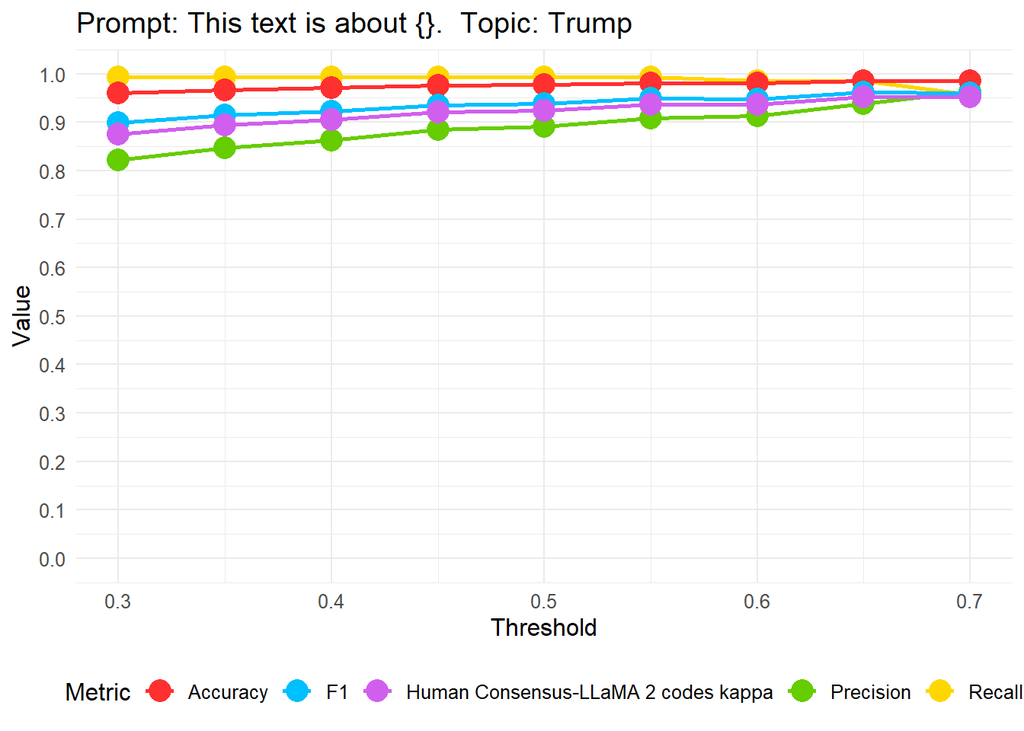

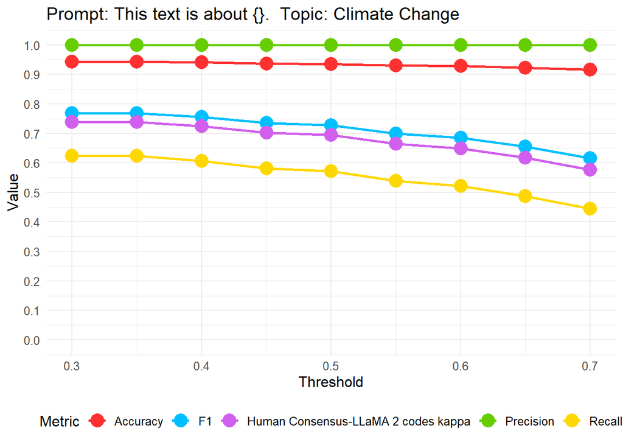

```r
for (i in 1:nrow(unique_combinations_LLaMA)) {
  hyp <- unique_combinations_LLaMA$hypothesis[i]
  top <- unique_combinations_LLaMA$topic[i]
  # Filter the data for the current combination
  subset <- results_pilot_LLaMA[results_pilot_LLaMA$hypothesis == hyp & results_pilot_LLaMA$topic == top, ]
  # Define the graphic
  plot <- ggplot(subset, aes(x = TH)) +
    geom_line(aes(y = recall, color = "Recall"), linewidth =  1) +
    geom_point(aes(y = recall, color = "Recall"), size =  5) +
    geom_line(aes(y = precision, color = "Precision"), linewidth =  1) +
    geom_point(aes(y = precision, color = "Precision"), size =  5) +
    geom_line(aes(y = accuracy, color = "Accuracy"), linewidth =  1) +
    geom_point(aes(y = accuracy, color = "Accuracy"), size =  5) +
    geom_line(aes(y = f1, color = "F1"), linewidth =  1) +
    geom_point(aes(y = f1, color = "F1"), size =  5) +
    geom_line(aes(y = kappa, color = "Human Consensus-LLaMA 2 codes kappa"), linewidth =  1) +
    geom_point(aes(y = kappa, color = "Human Consensus-LLaMA 2 codes kappa"), size =  5) +
    scale_color_manual(values = colors_LLaMA) +
    scale_y_continuous(limits=c(0,1),breaks=seq(0,1,by = 0.1))+
    labs(title = paste("Prompt:", hypothesis_LLaMA[as.numeric(unique_combinations_LLaMA$hyp[i])], " Topic:", labels_LLaMA[as.numeric(unique_combinations_LLaMA$top[i])]),
         x = "Threshold", y = "Value", color = "Metric") +
    theme_minimal() +
    theme(panel.background = element_rect(fill = "white", color = NA),
          legend.position = "bottom",
          text = element_text(size =  12))
  # Uncomment to save the figure
  filename <- sprintf("Results/Pilot/LLaMA/Metrics Evolution with Kappa/%s_%s_Evolution_of_Metrics_kappa.png", hyp, top)
ggsave(filename = filename, plot = plot, dpi = 300, width = 10, height = 6, bg = "white")
  print(plot)
}
```

#### Plot recall, accuracy, precision, f1 and Fleiss kappa across the threshold for LLM, Pilot.

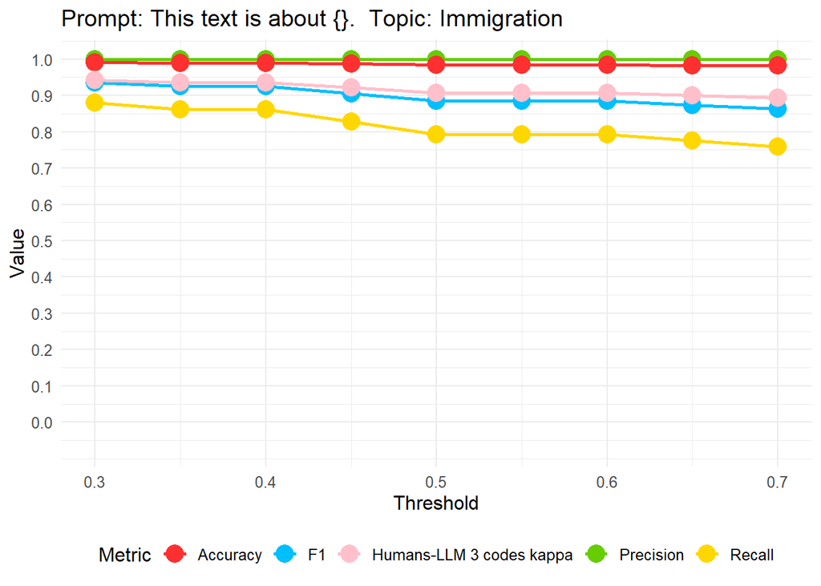

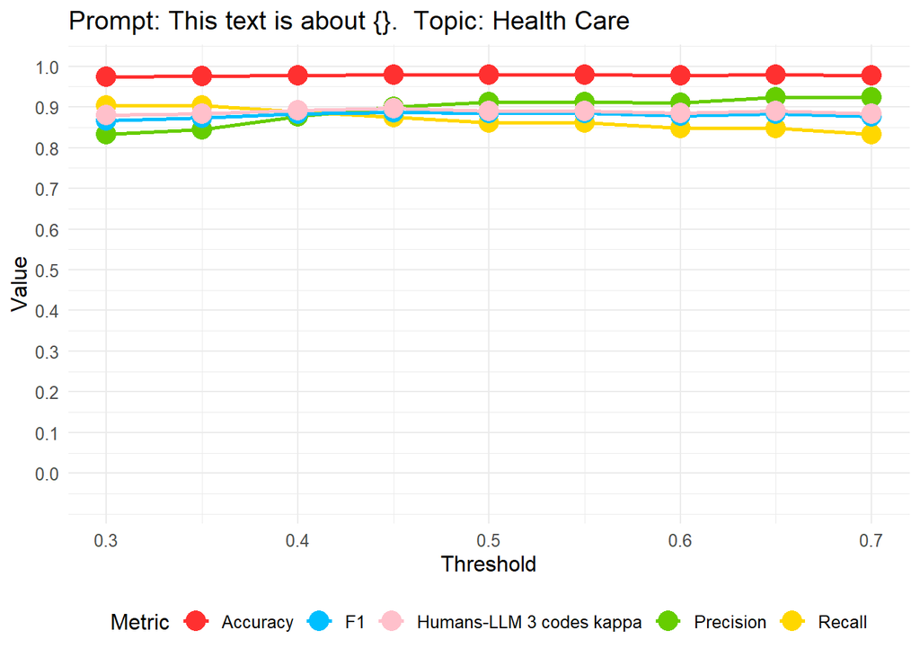

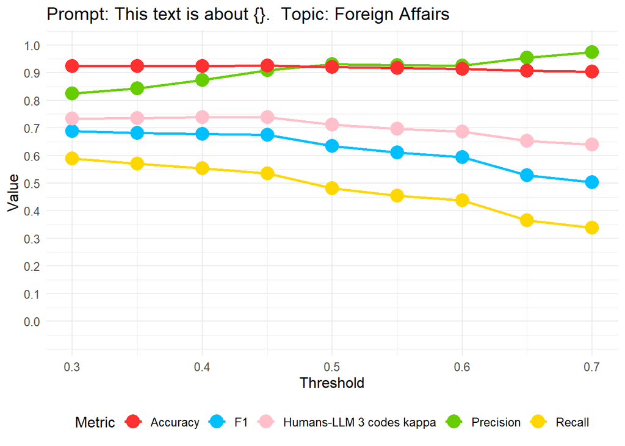

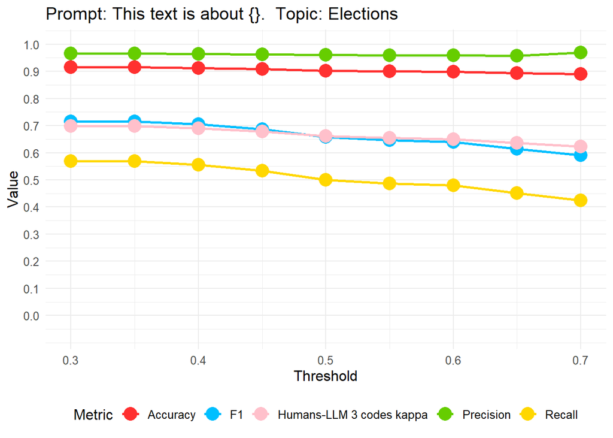

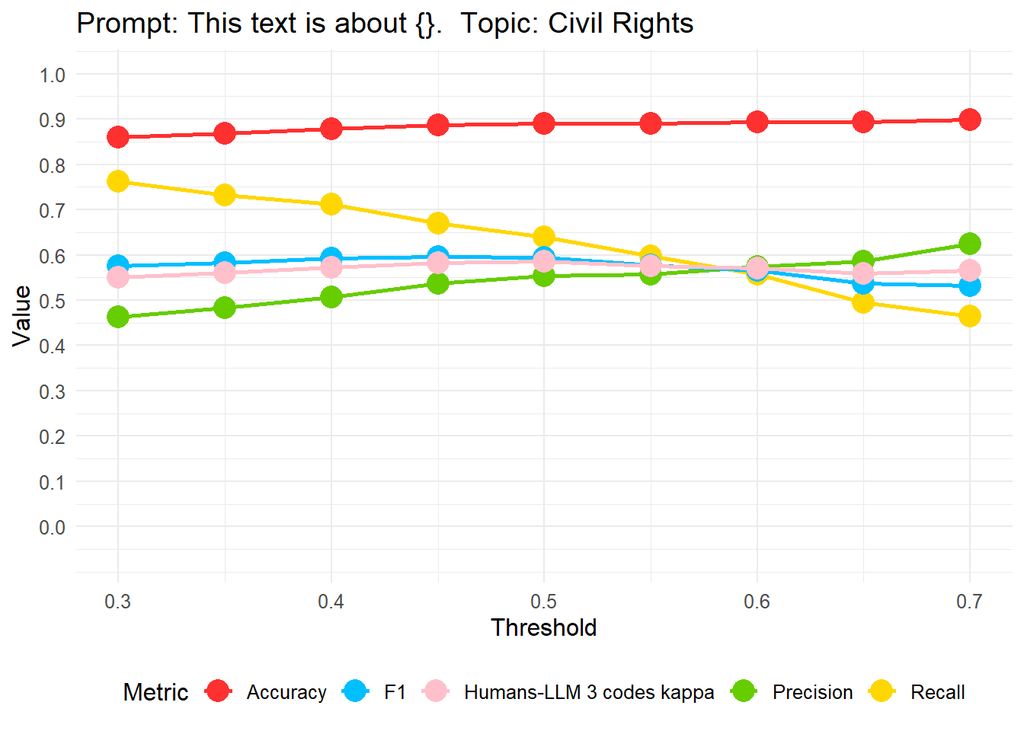

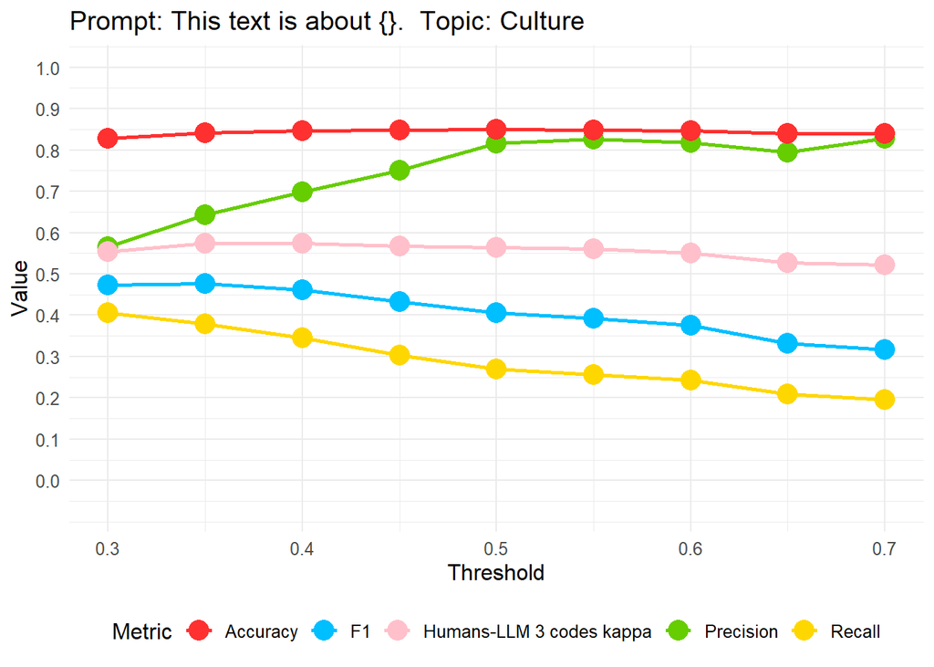

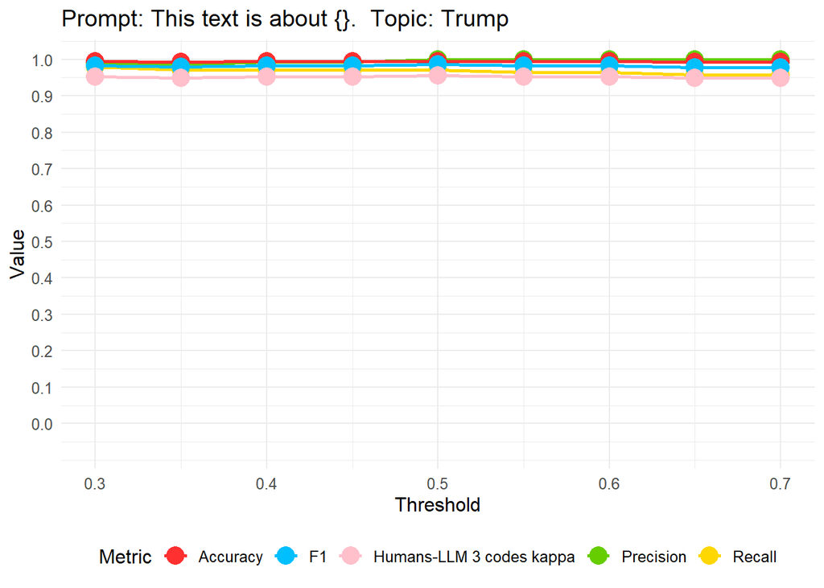

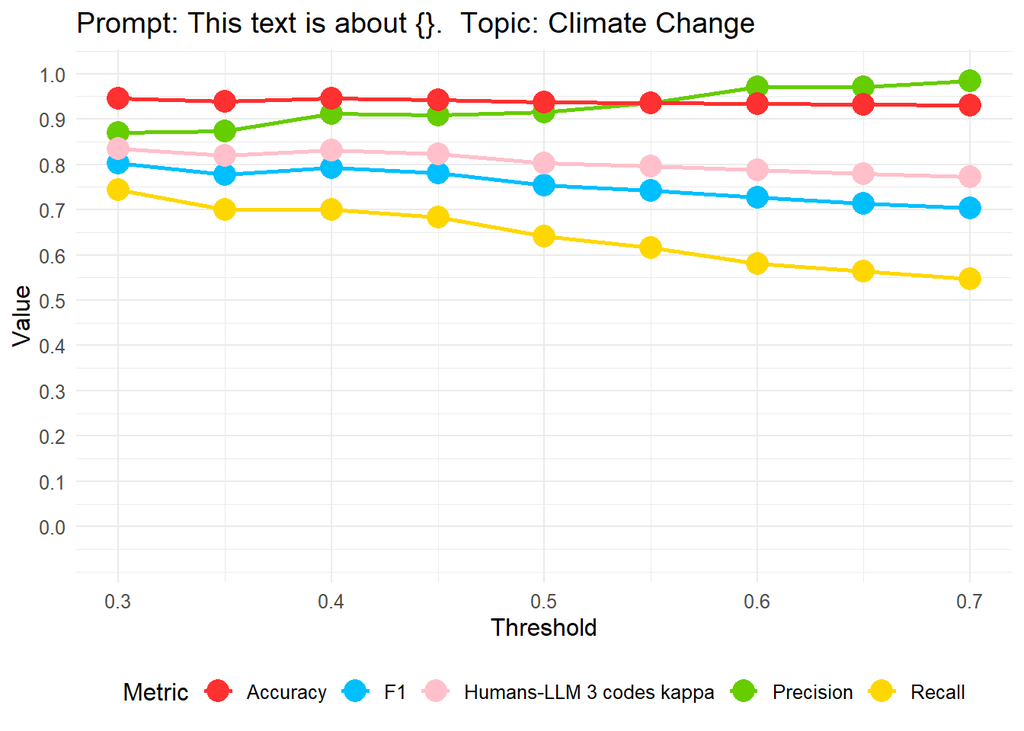

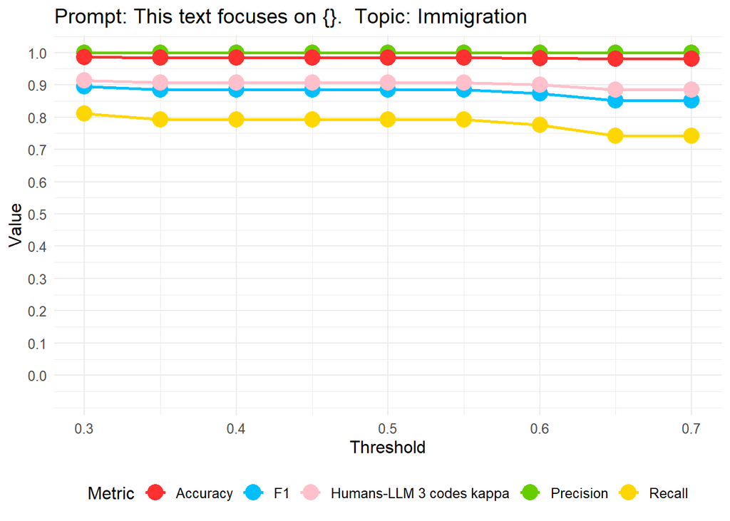

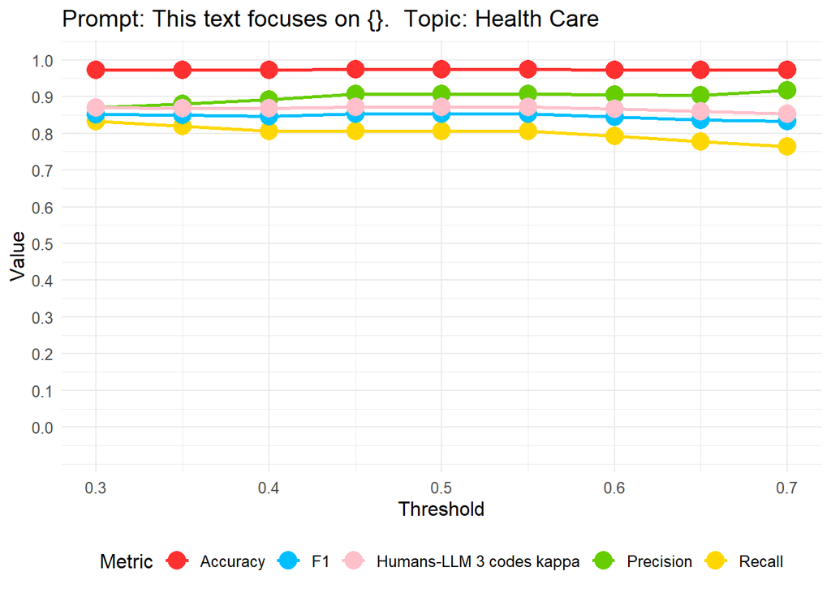

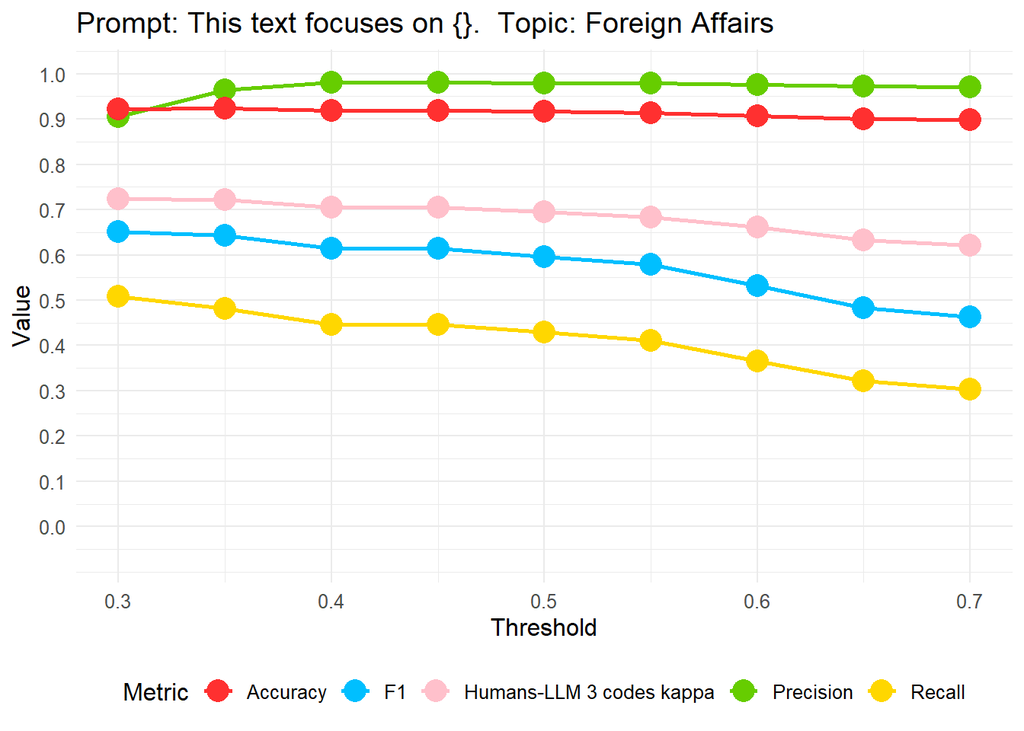

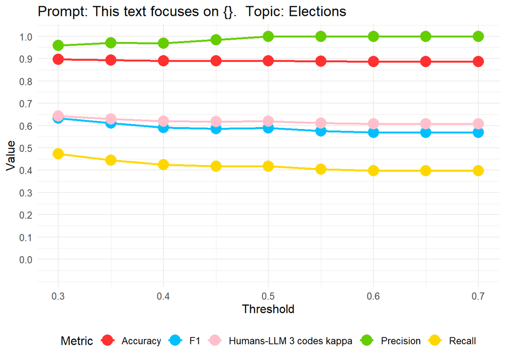

[20 more figures not shown]

```r
for (i in 1:nrow(unique_combinations_LLM)) {
  hyp <- unique_combinations_LLM$hypothesis[i]
  top <- unique_combinations_LLM$topic[i]

  # Filter the data for the current combination
  subset <- results_pilot_LLM[results_pilot_LLM$hypothesis == hyp & results_pilot_LLM$topic == top, ]
  plot <- ggplot(subset, aes(x = TH)) +
    geom_line(aes(y = recall, color = "Recall"), linewidth =  1) +
    geom_point(aes(y = recall, color = "Recall"), size =  5) +
    geom_line(aes(y = precision, color = "Precision"), linewidth =  1) +
    geom_point(aes(y = precision, color = "Precision"), size =  5) +
    geom_line(aes(y = accuracy, color = "Accuracy"), linewidth =  1) +
    geom_point(aes(y = accuracy, color = "Accuracy"), size =  5) +
    geom_line(aes(y = f1, color = "F1"), linewidth =  1) +
    geom_point(aes(y = f1, color = "F1"), size =  5) +
    geom_line(aes(y = kappa_fleiss, color = "Humans-LLM 3 codes kappa"), linewidth =  1) +
    geom_point(aes(y = kappa_fleiss, color = "Humans-LLM 3 codes kappa"), size =  5) +
    scale_color_manual(values = colors) +
    scale_y_continuous(limits=c(-0.07,1),breaks=seq(0,1,by = 0.1))+
    labs(title = paste("Prompt:", hypothesis_LLM[as.numeric(unique_combinations_LLM$hyp[i])], " Topic:", labels_LLM[as.numeric(unique_combinations_LLM$top[i])]),
         x = "Threshold", y = "Value", color = "Metric") +
    theme_minimal() +
    theme(panel.background = element_rect(fill = "white", color = NA),
          legend.position = "bottom",
          text = element_text(size =  12))
  # Uncomment to save the plot
  filename <- sprintf("Results/Pilot/LLM/With Kappa Fleiss/%s_%s_Evolution_of_Metrics_kappa_fleiss.png", hyp, top)
  ggsave(filename = filename, plot = plot, dpi = 300, width = 10, height = 6, bg = "white")
  print(plot)
}
```

#### Plot recall, accuracy, precision, f1 and Fleiss kappa across the threshold for LLaMA, Pilot.

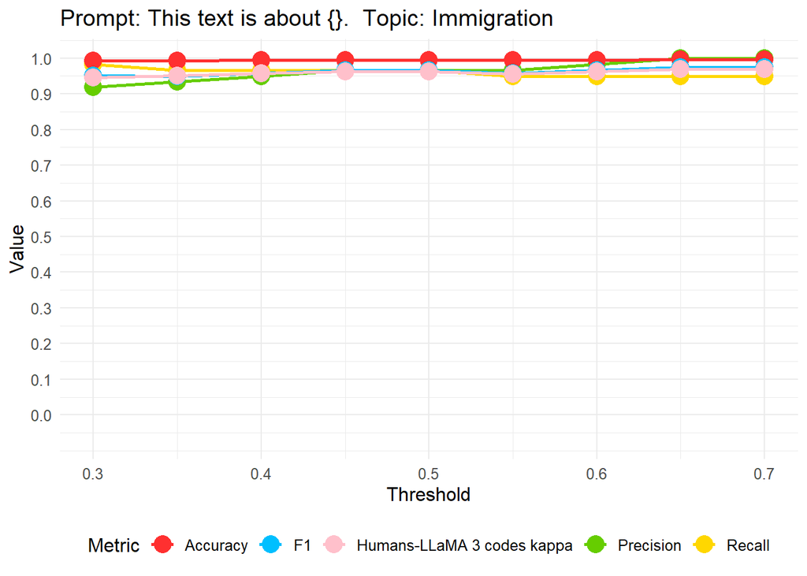

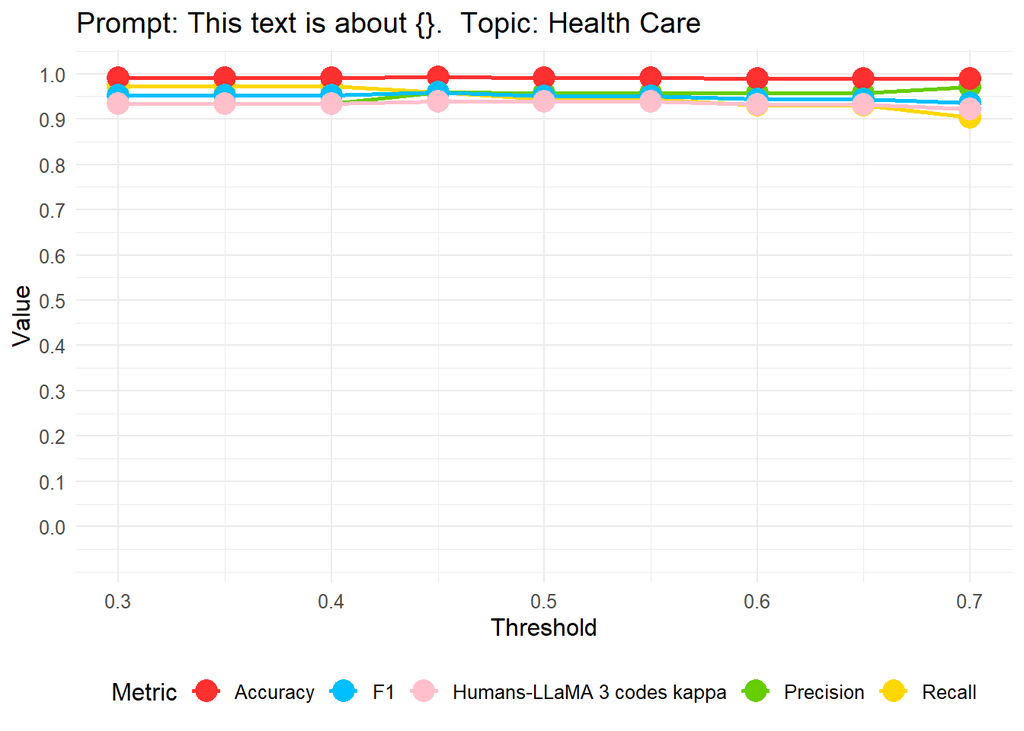

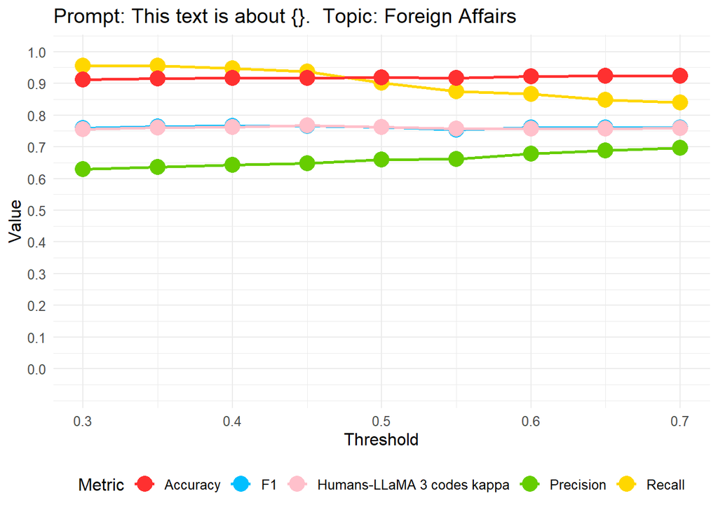

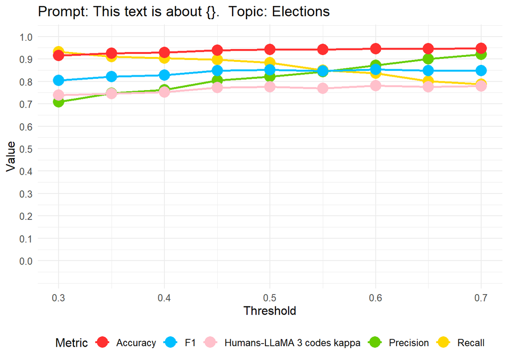

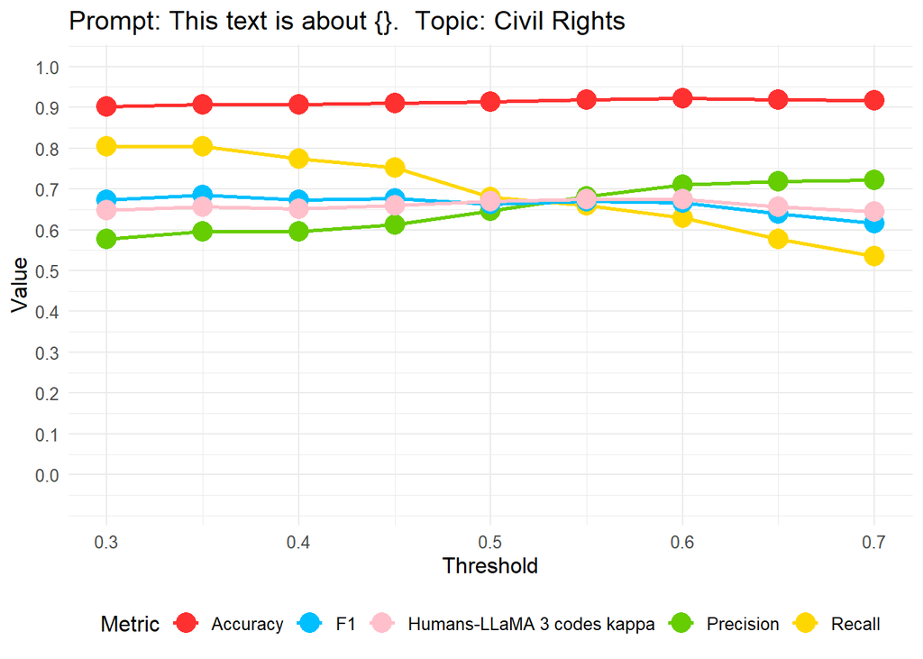

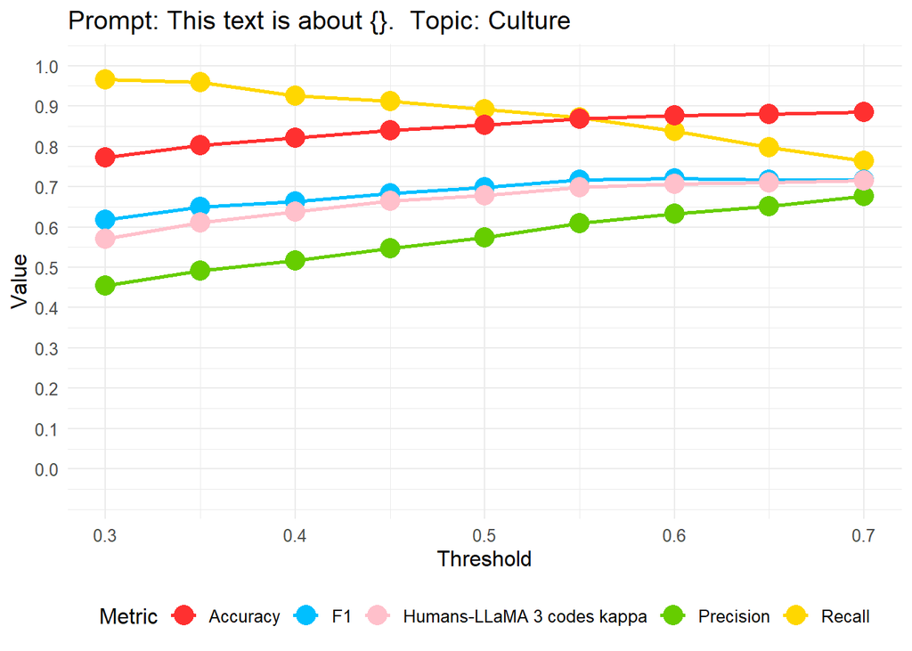

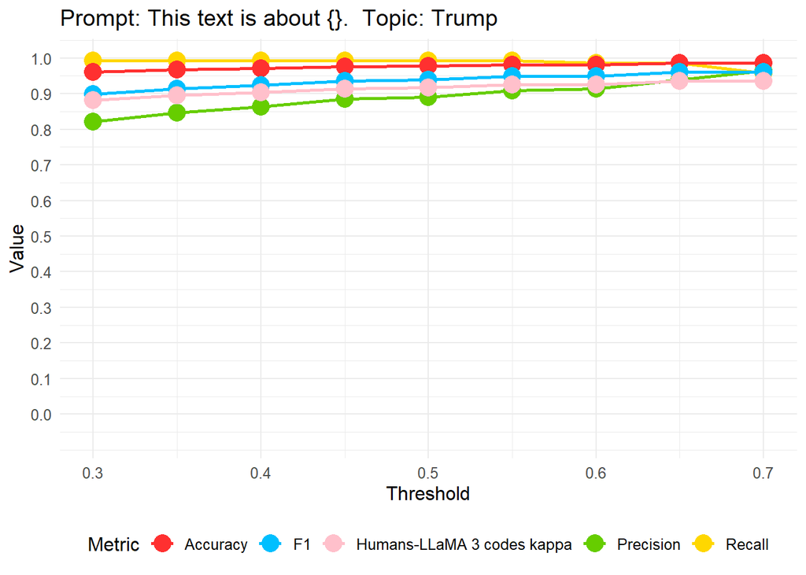

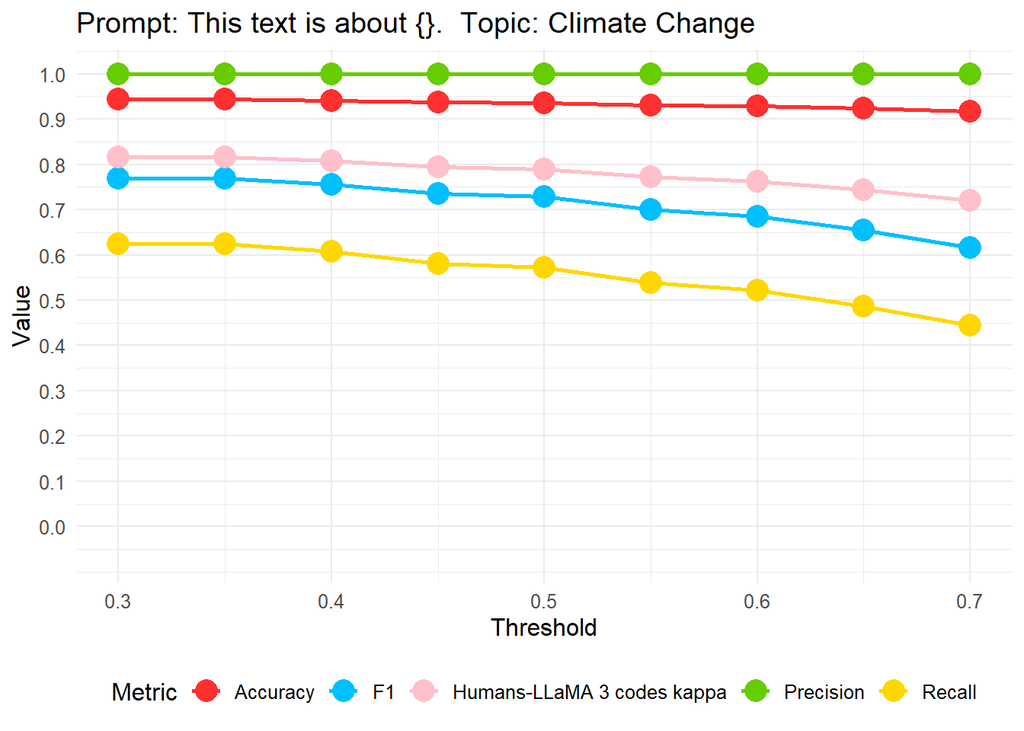

```r
for (i in 1:nrow(unique_combinations_LLaMA)) {
  hyp <- unique_combinations_LLaMA$hypothesis[i]
  top <- unique_combinations_LLaMA$topic[i]

  # Filter the data for the current combination
  subset <- results_pilot_LLaMA[results_pilot_LLaMA$hypothesis == hyp & results_pilot_LLaMA$topic == top, ]
  plot <- ggplot(subset, aes(x = TH)) +
    geom_line(aes(y = recall, color = "Recall"), linewidth =  1) +
    geom_point(aes(y = recall, color = "Recall"), size =  5) +
    geom_line(aes(y = precision, color = "Precision"), linewidth =  1) +
    geom_point(aes(y = precision, color = "Precision"), size =  5) +
    geom_line(aes(y = accuracy, color = "Accuracy"), linewidth =  1) +
    geom_point(aes(y = accuracy, color = "Accuracy"), size =  5) +
    geom_line(aes(y = f1, color = "F1"), linewidth =  1) +
    geom_point(aes(y = f1, color = "F1"), size =  5) +
    geom_line(aes(y = kappa_fleiss, color = "Humans-LLaMA 3 codes kappa"), linewidth =  1) +
    geom_point(aes(y = kappa_fleiss, color = "Humans-LLaMA 3 codes kappa"), size =  5) +
    scale_color_manual(values = colors_LLaMA) +
    scale_y_continuous(limits=c(-0.07,1),breaks=seq(0,1,by = 0.1))+
    labs(title = paste("Prompt:", hypothesis_LLaMA[as.numeric(unique_combinations_LLaMA$hyp[i])], " Topic:", labels_LLaMA[as.numeric(unique_combinations_LLaMA$top[i])]),
         x = "Threshold", y = "Value", color = "Metric") +
    theme_minimal() +
    theme(panel.background = element_rect(fill = "white", color = NA),
          legend.position = "bottom",
          text = element_text(size =  12))
  # Uncomment to save the plot
  filename <- sprintf("Results/Pilot/LLaMA/With Kappa Fleiss/%s_%s_Evolution_of_Metrics_kappa_fleiss.png", hyp, top)
  ggsave(filename = filename, plot = plot, dpi = 300, width = 10, height = 6, bg = "white")
  print(plot)
}
```

#### Plot different combinations of Cohen’s kappas and Fleiss’ Kappa for LLM, Pilot.

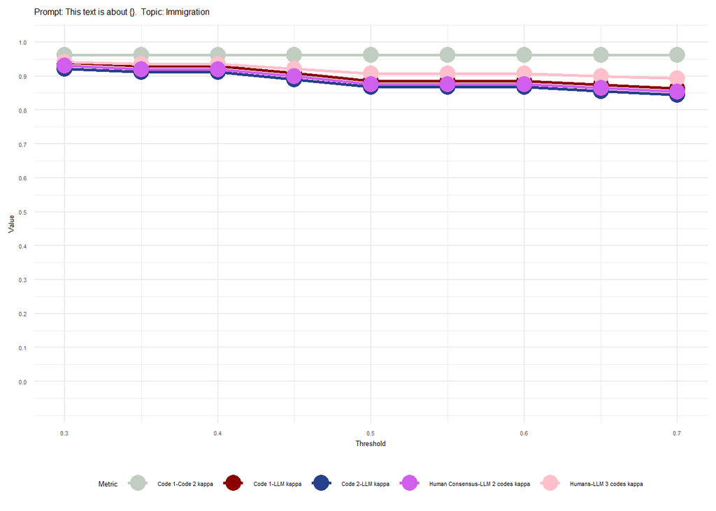

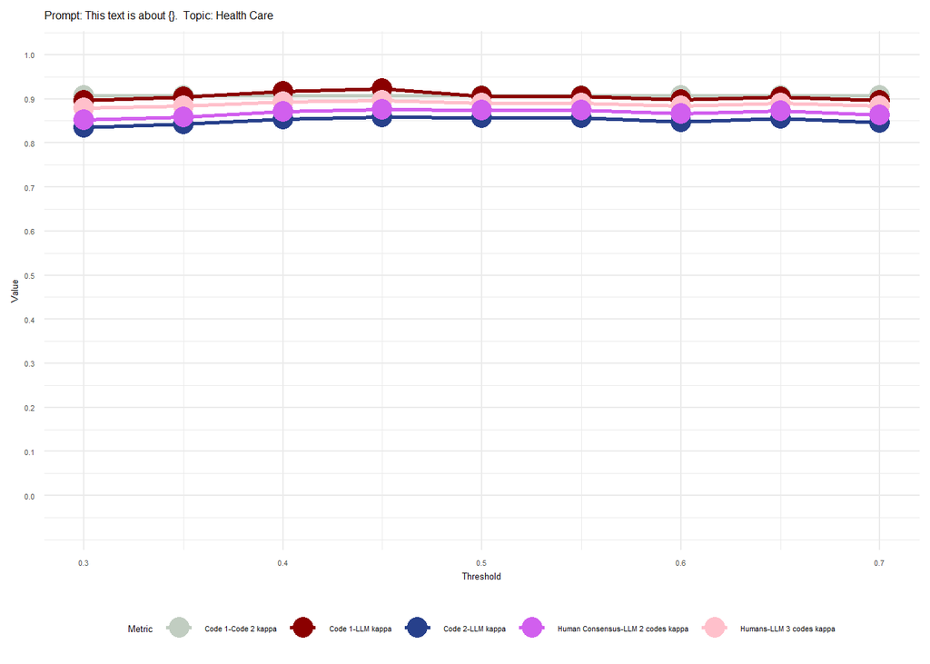

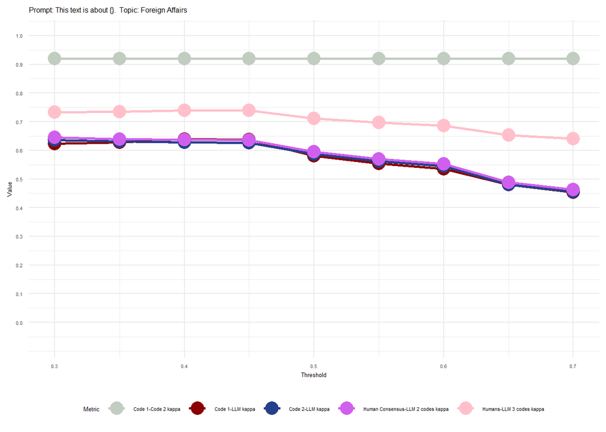

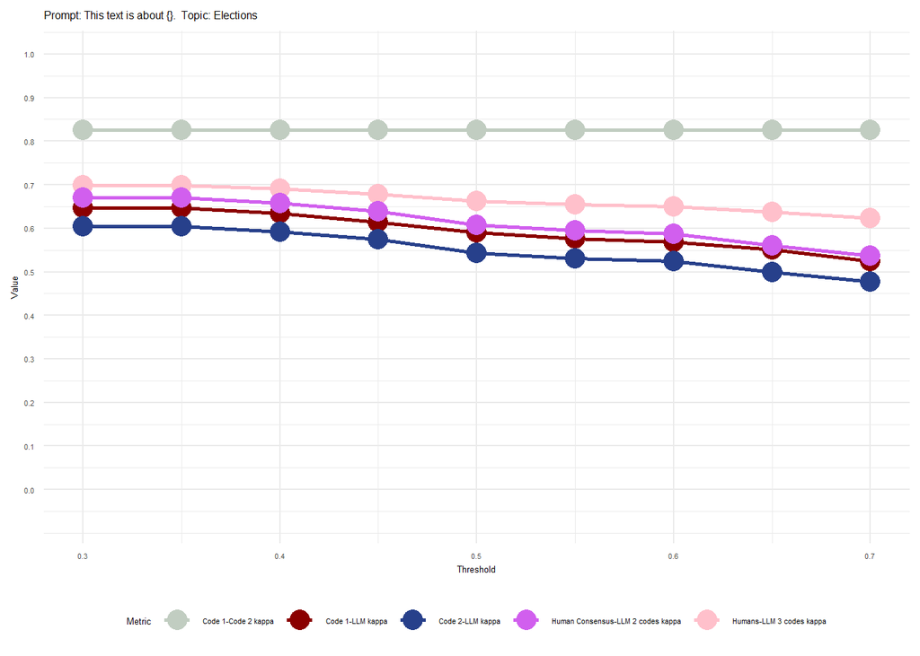

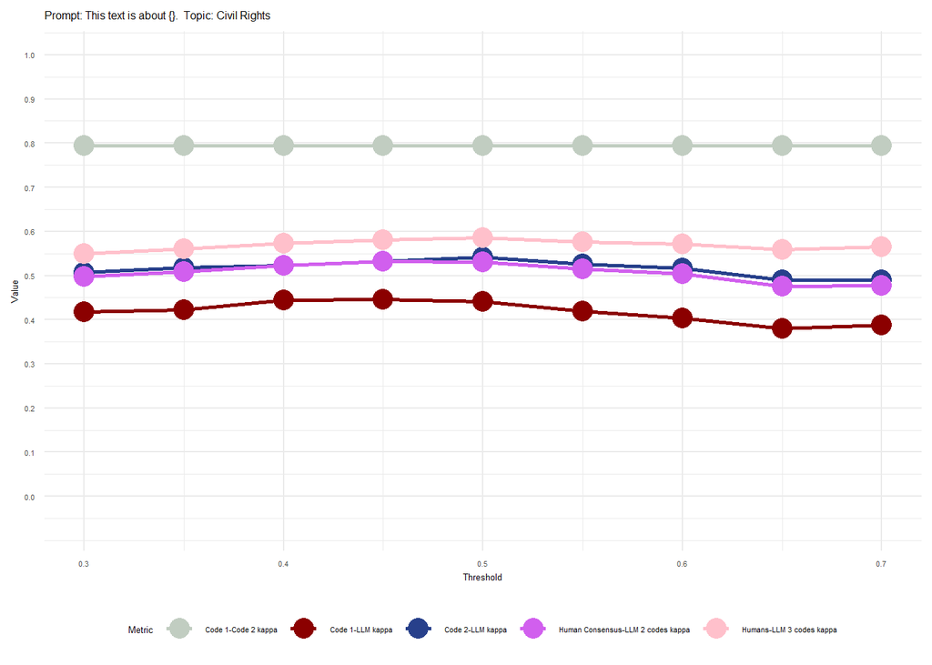

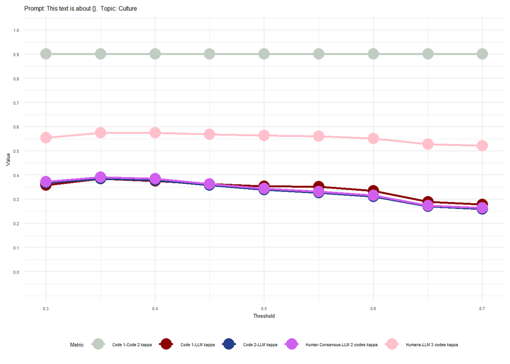

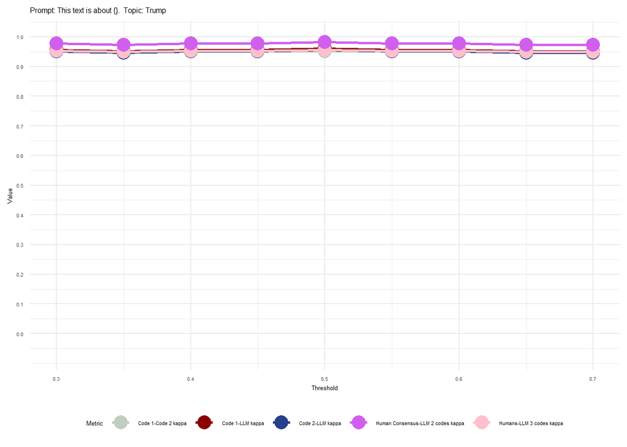

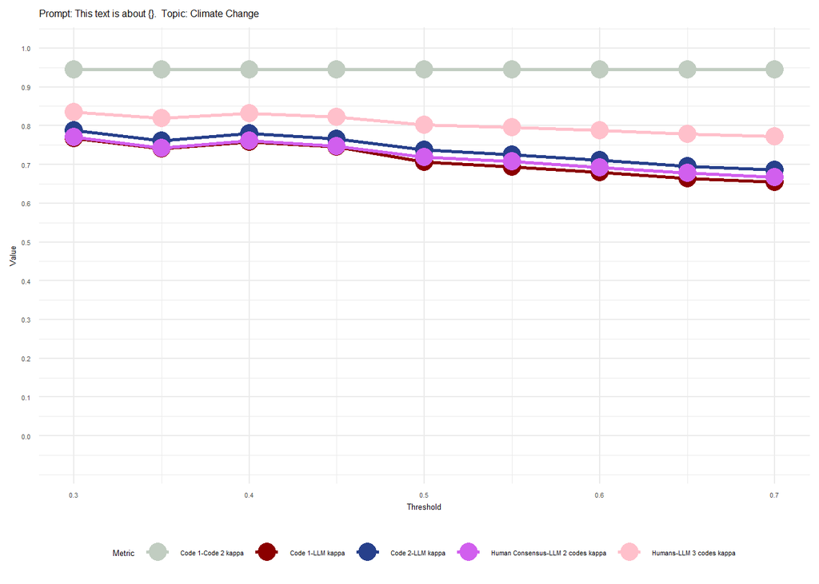

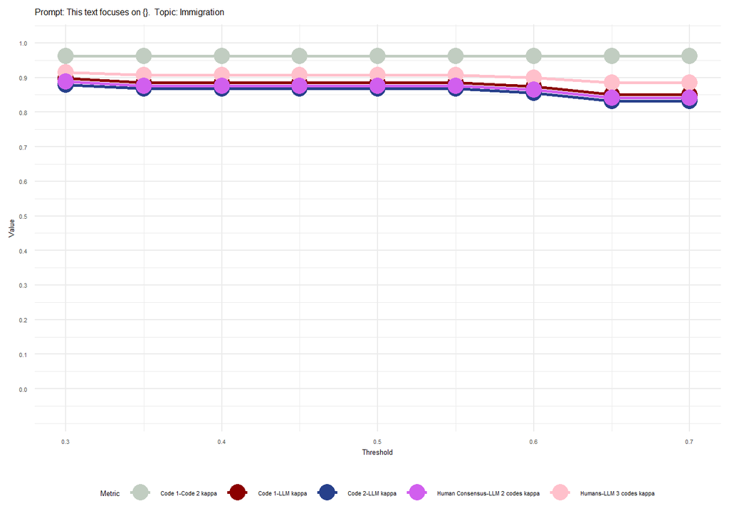

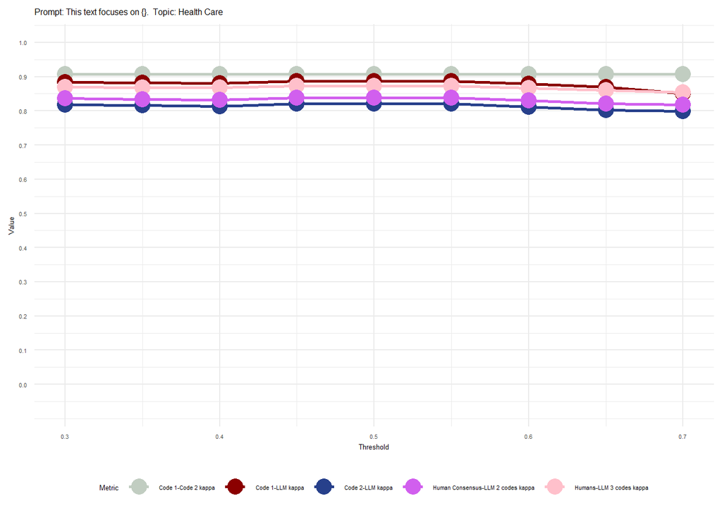

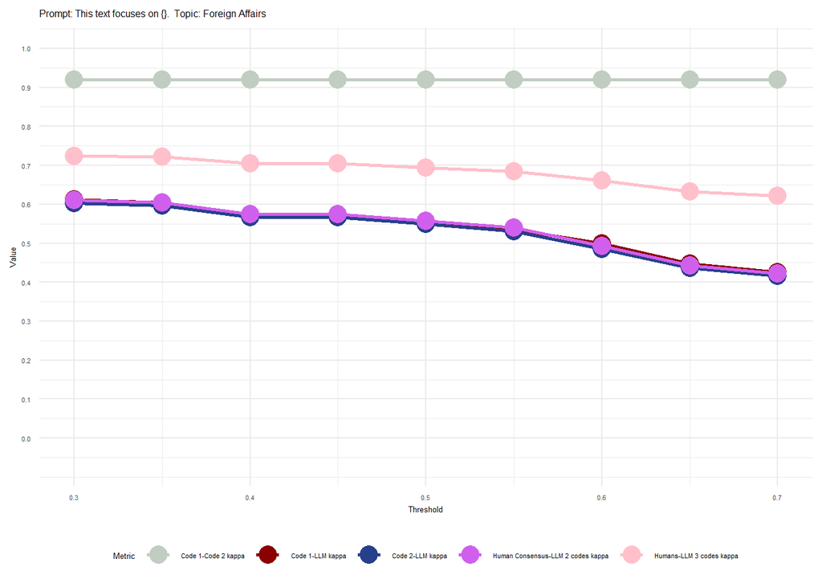

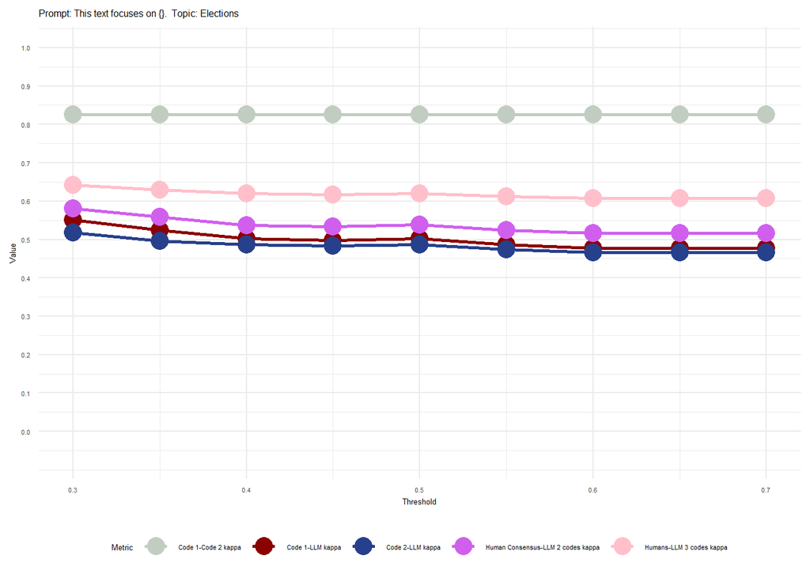

[20 more figures not shown]

```r
for (i in 1:nrow(unique_combinations_LLM)) {
    hyp <- unique_combinations_LLM$hypothesis[i]
    top <- unique_combinations_LLM$topic[i]

    # Filter the data for the current combination
    subset <- results_pilot_LLM[results_pilot_LLM$hypothesis == hyp & results_pilot_LLM$topic == top, ]

    # Define the graphic
    plot <- ggplot(subset, aes(x = TH)) +
      geom_line(aes(y = kappa_C1C2, color = "Code 1-Code 2 kappa"), linewidth =  1) +
      geom_point(aes(y = kappa_C1C2, color = "Code 1-Code 2 kappa"), size =  5) +
      geom_line(aes(y = kappa_C1BART, color = "Code 1-LLM kappa"), linewidth =  1) +
      geom_point(aes(y = kappa_C1BART, color = "Code 1-LLM kappa"), size =  5) +
      geom_line(aes(y = kappa_C2BART, color = "Code 2-LLM kappa"), linewidth =  1) +
      geom_point(aes(y = kappa_C2BART, color = "Code 2-LLM kappa"), size =  5) +
      geom_line(aes(y = kappa_fleiss, color = "Humans-LLM 3 codes kappa"), linewidth =  1) +
      geom_point(aes(y = kappa_fleiss, color = "Humans-LLM 3 codes kappa"), size =  5) +
      geom_line(aes(y = kappa, color = "Human Consensus-LLM 2 codes kappa"), linewidth =  1) +
      geom_point(aes(y = kappa, color = "Human Consensus-LLM 2 codes kappa"), size =  5) +
      scale_color_manual(values = colors) +
      scale_y_continuous(limits=c(-0.07,1),breaks=seq(0,1,by = 0.1))+
      labs(title = paste("Prompt:", hypothesis_LLM[as.numeric(unique_combinations_LLM$hyp[i])], " Topic:", labels_LLM[as.numeric(unique_combinations_LLM$top[i])]),
           x = "Threshold", y = "Value", color = "Metric") +
      theme_minimal() +
      theme(panel.background = element_rect(fill = "white", color = NA),
            legend.position = "bottom",
            text = element_text(size =  5))
   # Uncomment to save the plot
    filename <- sprintf("Results/Pilot/LLM/kappas evolution/%s_%s_Evolution_of_kappas.png", hyp, top)
    ggsave(filename = filename, plot = plot, dpi = 300, width = 10, height = 6, bg = "white")
    print(plot)
}
```

#### Plot different combinations of Cohen’s kappas and Fleiss’ Kappa for LLaMA, Pilot.

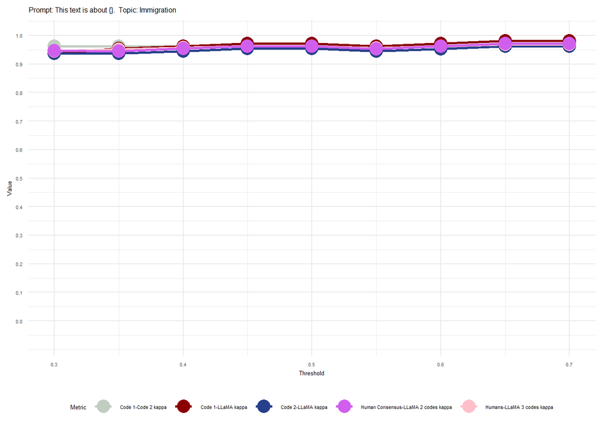

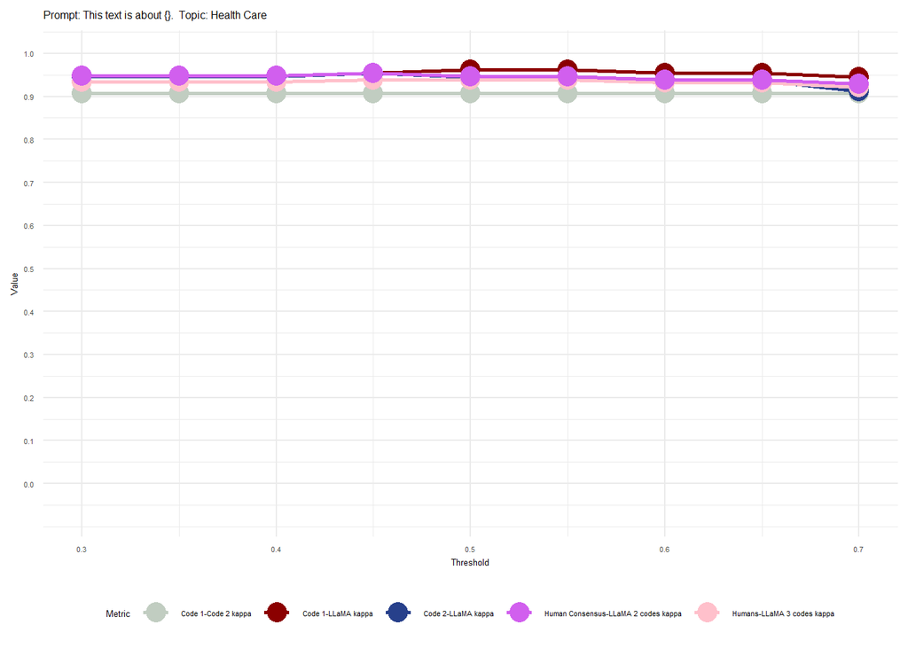

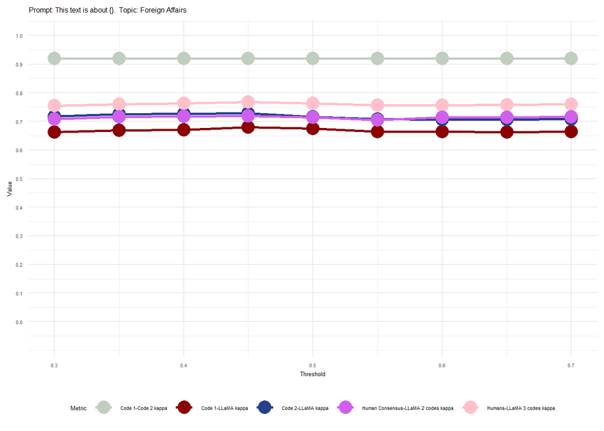

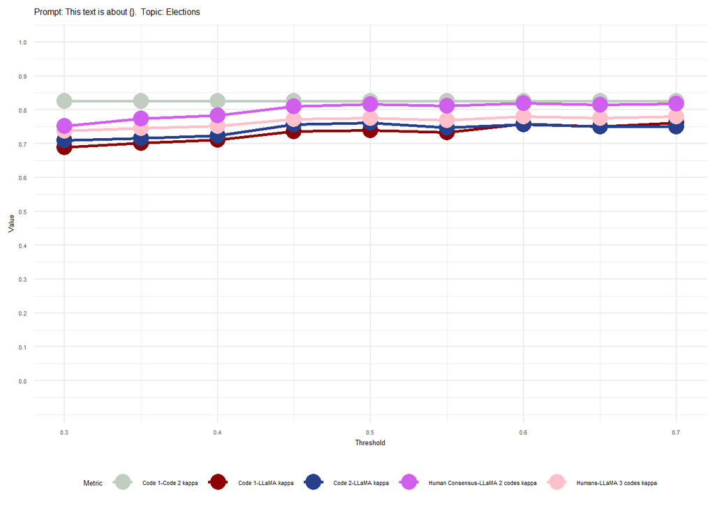

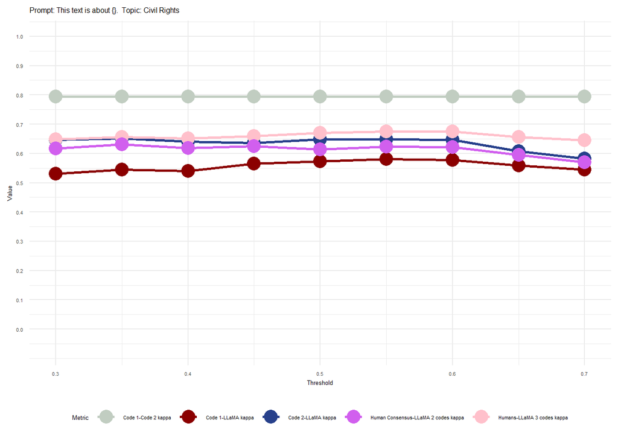

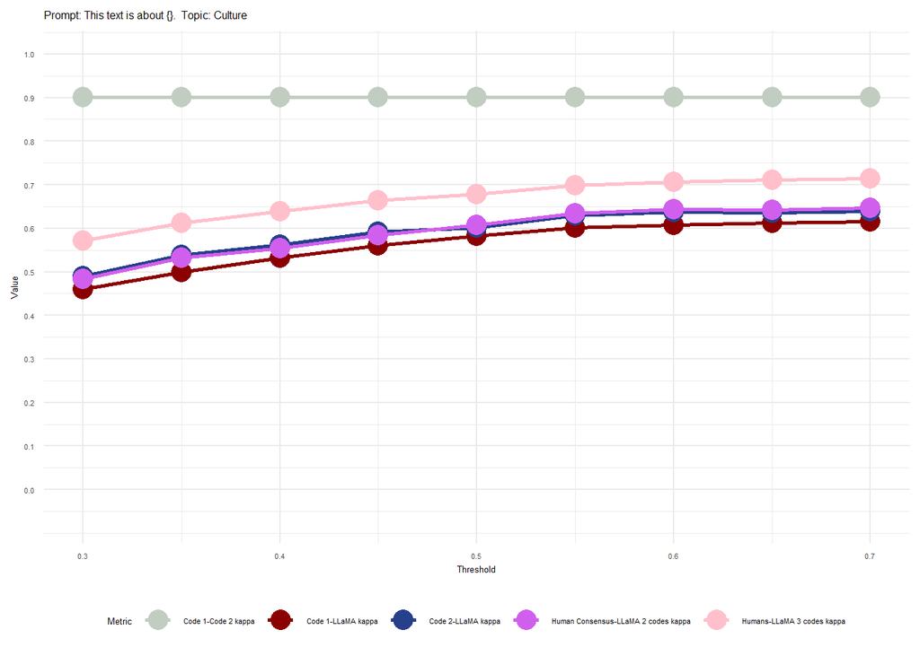

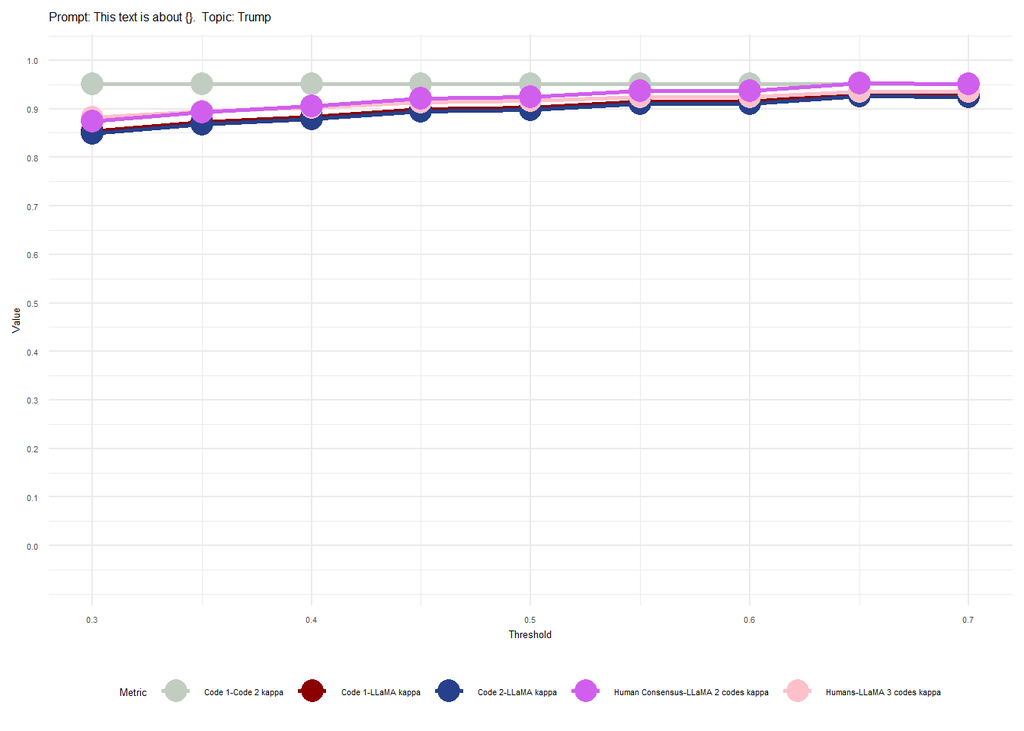

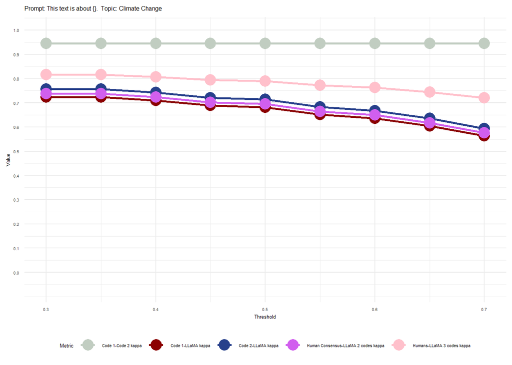

```r
for (i in 1:nrow(unique_combinations_LLaMA)) {
    hyp <- unique_combinations_LLaMA$hypothesis[i]
    top <- unique_combinations_LLaMA$topic[i]

    # Filter the data for the current combination
    subset <- results_pilot_LLaMA[results_pilot_LLaMA$hypothesis == hyp & results_pilot_LLaMA$topic == top, ]

    # Define the graphic
    plot <- ggplot(subset, aes(x = TH)) +
      geom_line(aes(y = kappa_C1C2, color = "Code 1-Code 2 kappa"), linewidth =  1) +
      geom_point(aes(y = kappa_C1C2, color = "Code 1-Code 2 kappa"), size =  5) +
      geom_line(aes(y = kappa_C1LLaMA, color = "Code 1-LLaMA kappa"), linewidth =  1) +
      geom_point(aes(y = kappa_C1LLaMA, color = "Code 1-LLaMA kappa"), size =  5) +
      geom_line(aes(y = kappa_C2LLaMA, color = "Code 2-LLaMA kappa"), linewidth =  1) +
      geom_point(aes(y = kappa_C2LLaMA, color = "Code 2-LLaMA kappa"), size =  5) +
      geom_line(aes(y = kappa_fleiss, color = "Humans-LLaMA 3 codes kappa"), linewidth =  1) +
      geom_point(aes(y = kappa_fleiss, color = "Humans-LLaMA 3 codes kappa"), size =  5) +
      geom_line(aes(y = kappa, color = "Human Consensus-LLaMA 2 codes kappa"), linewidth =  1) +
      geom_point(aes(y = kappa, color = "Human Consensus-LLaMA 2 codes kappa"), size =  5) +
      scale_color_manual(values = colors_LLaMA) +
      scale_y_continuous(limits=c(-0.07,1),breaks=seq(0,1,by = 0.1))+
      labs(title = paste("Prompt:", hypothesis_LLaMA[as.numeric(unique_combinations_LLaMA$hyp[i])], " Topic:", labels_LLaMA[as.numeric(unique_combinations_LLaMA$top[i])]),
           x = "Threshold", y = "Value", color = "Metric") +
      theme_minimal() +
      theme(panel.background = element_rect(fill = "white", color = NA),
            legend.position = "bottom",
            text = element_text(size =  5))
   # Uncomment to save the plot
    filename <- sprintf("Results/Pilot/LLaMA/kappas evolution/%s_%s_Evolution_of_kappas.png", hyp, top)
    ggsave(filename = filename, plot = plot, dpi = 300, width = 10, height = 6, bg = "white")
    print(plot)
  }
```

#### Analysis of F1 for LLM

Next, a detailed analysis of the F1 score is conducted

```r
# Step 1: Create a list to store the tables for each hypothesis
hypothesis_tables <- list()

# Step 2: Loop through each hypothesis to create the corresponding table
for (hyp in unique(results_df$hypothesis)) {
  # Filter the data for the current hypothesis
  hypothesis_data <- results_df %>%filter(hypothesis == hyp)

# Step 3: For each topic, find the maximum F1 score and the corresponding thresholds and accuracy

   max_f1_table <- hypothesis_data %>%
    group_by(topic) %>%
    # Find the maximum F1 score for each topic
    mutate(max_f1 = max(f1)) %>%
    # Filter rows where F1 is equal to the maximum F1 score
    filter(f1 == max_f1) %>%
    # Arrange by TH (threshold) to keep all thresholds where the max F1 is achieved
    arrange(topic, TH) %>%
    # Summarize the results for each topic, keeping the max F1, thresholds, and accuracy
    summarise(
      max_f1 = first(max_f1),  # Maximum F1 score (all rows will have the same value)
      thresholds = paste(TH, collapse = ", "),  # Thresholds where max F1 is achieved
      accuracy = first(accuracy)  # Accuracy corresponding to max F1 score
    ) %>%
    ungroup()

  # Store the table for the current hypothesis in the list
  hypothesis_tables[[hyp]] <- max_f1_table
}
```

Now `hypothesis_tables` contains a table for each hypothesis. Access the table for a specific hypothesis like this: `hypothesis_tables[["Hypothesis1"]]`.

```r
print(hypothesis_tables[[1]]) #This text is about
```

```
## # A tibble: 8 × 4
##   topic max_f1 thresholds accuracy
##   <chr>  <dbl> <chr>         <dbl>
## 1 1      0.936 0.3           0.991
## 2 2      0.887 0.45          0.979
## 3 3      0.688 0.3           0.923
## 4 4      0.716 0.3, 0.35     0.915
## 5 5      0.596 0.45          0.887
## 6 6      0.477 0.35          0.842
## 7 7      0.985 0.5           0.995
## 8 8      0.802 0.3           0.945
```

```r
print(hypothesis_tables[[2]]) #This text focuses on
```

```
## # A tibble: 8 × 4
##   topic max_f1 thresholds      accuracy
##   <chr>  <dbl> <chr>              <dbl>
## 1 1      0.895 0.3                0.986
## 2 2      0.853 0.45, 0.5, 0.55    0.974
## 3 3      0.651 0.3                0.921
## 4 4      0.633 0.3                0.897
## 5 5      0.510 0.35               0.871
## 6 6      0.317 0.3                0.834
## 7 7      0.982 0.4, 0.45, 0.5     0.994
## 8 8      0.747 0.35, 0.4          0.936
```

```r
print(hypothesis_tables[[3]]) #The main subject of this text is
```

```
## # A tibble: 8 × 4
##   topic max_f1 thresholds accuracy
##   <chr>  <dbl> <chr>         <dbl>
## 1 1      0.84  0.35          0.979
## 2 2      0.827 0.35          0.970
## 3 3      0.575 0.3           0.912
## 4 4      0.598 0.3           0.889
## 5 5      0.506 0.35          0.892
## 6 6      0.395 0.3           0.803
## 7 7      0.951 0.3           0.983
## 8 8      0.687 0.3           0.921
```

```r
print(hypothesis_tables[[4]]) #This text is related to
```

```
## # A tibble: 8 × 4
##   topic max_f1 thresholds accuracy
##   <chr>  <dbl> <chr>         <dbl>
## 1 1      0.755 0.7           0.955
## 2 2      0.714 0.7           0.928
## 3 3      0.464 0.7           0.705
## 4 4      0.600 0.7           0.780
## 5 5      0.501 0.7           0.775
## 6 6      0.347 0.7           0.326
## 7 7      0.932 0.7           0.974
## 8 8      0.743 0.7           0.907
```

## Analysis of 0.4 threshold for LLM, Pilot Study. Part of the Figure 3. Appendix B.

Preliminary analyses of the metrics allow focusing the process on the 0.4 threshold. Below is the graph presented in Figure 3 of the manuscript.

We generate a large, high‑resolution plot for saving and publication, and a smaller simplified version for direct visualization inside RStudio.

```r
results_04 <- results_pilot_LLM[results_pilot_LLM$TH == "0.4",]
results_04H1 <- results_04[results_04$hypothesis == "1",]
results_04H1$topic_names<-c('Immigration','Health Care','Foreign Affairs', 'Elecctions', 'Civil Rights','Culture','Trump','Climate Change')

results_long <- results_04H1 %>%
  pivot_longer(
    cols=c(accuracy,precision,recall,
           f1,kappa_fleiss,kappa),
    names_to="Metric",
    values_to="Value"
  )

results_long$Metric <- factor(
  results_long$Metric,
  levels=c("accuracy","precision","recall",
           "f1","kappa_fleiss","kappa"),
  labels=c("Accuracy",
           "Precision",
           "Recall",
           "F1",
           "Humans-LLM 3 codes kappa",
           "Human Consensus-LLM 2 codes kappa")
)
```

We generate a large, high‑resolution plot for saving and publication, and a smaller simplified version for direct visualization inside RStudio.

```r
plot <- ggplot(results_long,
               aes(topic_names, Value, fill=Metric))+

    geom_col(position=position_dodge(.8),
             width=.5,
             alpha=.35)+

    geom_point(aes(colour=Metric),
               position=position_dodge(.8),
               size=9)+

    scale_fill_manual(values=colors)+
    scale_colour_manual(values=colors)+

    scale_y_continuous(limits=c(0,1),
                       breaks=seq(0,1,.2))+

    labs(x="",y="Value",
         fill="Metric",
         colour="Metric")+

    theme_minimal()+
  theme(
    legend.position = "bottom",
      legend.margin = margin(t = 0),
    legend.spacing.y = unit(0.2, "cm"),
    plot.margin = margin(b = 2, t = 5),
    text = element_text(size = 28),
    axis.text.x = element_text(size = 28, angle = 60, hjust =0.8, vjust=1, face='bold'),
    axis.text.y = element_text(size = 28),
    axis.title = element_text(size = 28),
    legend.title = element_text(size = 30),
    legend.text = element_text(size = 28)
)

ggsave("Results/Pilot/LLM/New_BarsPoints4_pilot_LLM.png",    plot,width=23,height=13,bg="white")
```

The following version ensures the full plot renders correctly inside RStudio.

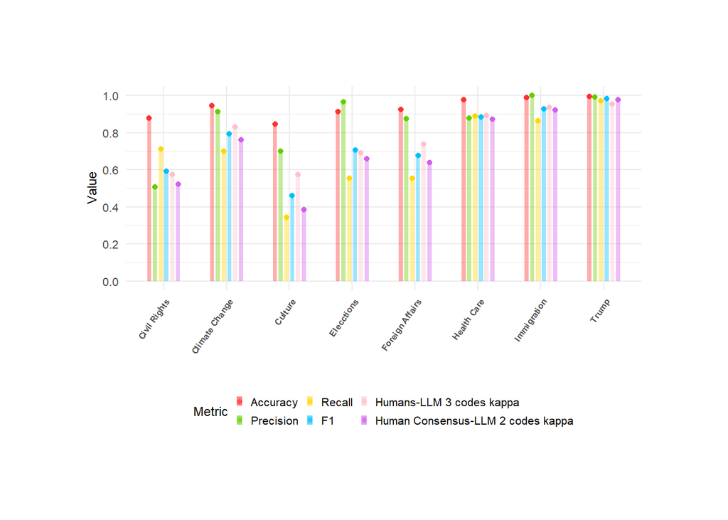

```r
plot_view <- ggplot(results_long,
                    aes(topic_names, Value, fill = Metric)) +

  # Large but balanced bars
  geom_col(position = position_dodge(width = 0.55),
           width = 0.4,        # wide bars, but not too wide
           alpha = 0.4) +      # lighter fill for clarity

  # Small points for clarity
  geom_point(aes(colour = Metric),
             position = position_dodge(width = 0.55),
             size = 1.5) +

  # Manual color scales
  scale_fill_manual(values = colors) +
  scale_colour_manual(values = colors) +

  # Y-axis limits and breaks
  scale_y_continuous(limits = c(0, 1),
                     breaks = seq(0, 1, 0.2)) +

  # Axis labels
  labs(x = "",
       y = "Value",
       fill = "Metric",
       colour = "Metric") +

  # Prevent clipping of long labels
  coord_cartesian(clip = "off") +

  # Compact legend (single guide)
  guides(
    fill = guide_legend(
      override.aes = list(size = 1.2, alpha = 0.6),
      ncol = 3
    )
  ) +

  # Theme adjustments for RStudio visibility
  theme_minimal() +
  theme(
    legend.position = "bottom",
    legend.box = "horizontal",
    legend.key.size = unit(0.3, "lines"),
    legend.spacing.x = unit(0.15, "lines"),

    # General text size
    text = element_text(size = 9),

    # X-axis labels
    axis.text.x = element_text(size = 6, angle = 55, hjust = 1, face = "bold", margin = margin(t = 2)),

    # Y-axis labels
    axis.text.y = element_text(size = 8),

    # Axis titles
    axis.title = element_text(size = 9),

    # Legend text
    legend.title = element_text(size = 9),
    legend.text  = element_text(size = 8),

    # Panel margins (balanced)
    plot.margin = margin(60, 60, 60, 60)
  )
print(plot_view)
```

We then proceeded with a correlation analysis, the results of which are reported in Table A2 in the Appendix.

```r
# Generate names with structure hypothesis/topics
column_names <- as.vector(outer(labels, hypothesis, paste, sep = "_"))
# Rename variables to automatically calculate correlation matrices
colnames(LLM)[3:34] <- column_names

# List to store the correlation matrices
correlation_matrices <- list()

# Iterate over the topics
for (topic in labels) {
  # Select the columns for the topic with the different hypotheses
  columns_to_select <- paste(topic, hypothesis, sep = "_")
  selected_columns <- LLM[, columns_to_select]

  # Calculate the correlation matrix
  cor_matrix <- cor(selected_columns, use = "complete.obs")
  # Use "complete.obs" to omit NA values if needed

  # Store the correlation matrix in the list
  correlation_matrices[[topic]] <- cor_matrix
}

# View the correlation matrix for a specific topic, for example, "Immigration"
print(correlation_matrices[["Immigration"]])
```

```
##               Immigration_1
## Immigration_1             1
```

```r
corr_foraff = correlation_matrices[["Foreign Affairs"]]
corr_culture = correlation_matrices[["Culture"]]
corr_immigration = correlation_matrices[["Immigration"]]
corr_trump = correlation_matrices[["Trump"]]
corr_health = correlation_matrices[["Health Care"]]
corr_elections = correlation_matrices[["Elections"]]
corr_civ_rights= correlation_matrices[["Civil Rights"]]
corr_EnvEnCli = correlation_matrices[["Climate Change"]]
```

## Analysis of 0.4 threshold for LLaMA, Pilot Study. Bottom part of the Figure 3. Appendix

Preliminary analyses of the metrics allow focusing the process on the 0.4 threshold. Below is the graph presented in Figure 3 of the manuscript.

```r
results_04 <- results_pilot_LLaMA[results_pilot_LLaMA$TH == "0.4",]
results_04H1 <- results_04[results_04$hypothesis == "1",]
results_04H1$topic_names<-c('Immigration','Health Care','Foreign Affairs', 'Elecctions', 'Civil Rights','Culture','Trump','Climate Change')



results_long <- results_04H1 %>%
  pivot_longer(
    cols=c(accuracy,precision,recall,
           f1,kappa_fleiss,kappa),
    names_to="Metric",
    values_to="Value"
  )

results_long$Metric <- factor(
  results_long$Metric,
  levels=c("accuracy","precision","recall",
           "f1","kappa_fleiss","kappa"),
  labels=c("Accuracy",
           "Precision",
           "Recall",
           "F1",
           "Humans-LLaMA 3 codes kappa",
           "Human Consensus-LLaMA 2 codes kappa")
)
```

```r
plot <- ggplot(results_long,
               aes(topic_names, Value, fill=Metric))+

    geom_col(position=position_dodge(.8),
             width=.5,
             alpha=.35)+

    geom_point(aes(colour=Metric),
               position=position_dodge(.8),
               size=9)+

    scale_fill_manual(values=colors_LLaMA)+
    scale_colour_manual(values=colors_LLaMA)+

    scale_y_continuous(limits=c(0,1),
                       breaks=seq(0,1,.2))+

    labs(x="",y="Value",
         fill="Metric",
         colour="Metric")+

    theme_minimal()+
  theme(
    legend.position = "bottom",
      legend.margin = margin(t = 0),
    legend.spacing.y = unit(0.2, "cm"),
    plot.margin = margin(b = 2, t = 5),
    text = element_text(size = 28),
    axis.text.x = element_text(size = 28, angle = 60, hjust =0.8, vjust=1, face='bold'),
    axis.text.y = element_text(size = 28),
    axis.title = element_text(size = 28),
    legend.title = element_text(size = 30),
    legend.text = element_text(size = 28)
)

ggsave("Results/Pilot/LLaMA/New_BarsPoints4_pilot_LLaMA.png",      plot,width=23,height=13,bg="white")

#print(plot)
```

The following version ensures the full plot renders correctly inside RStudio.

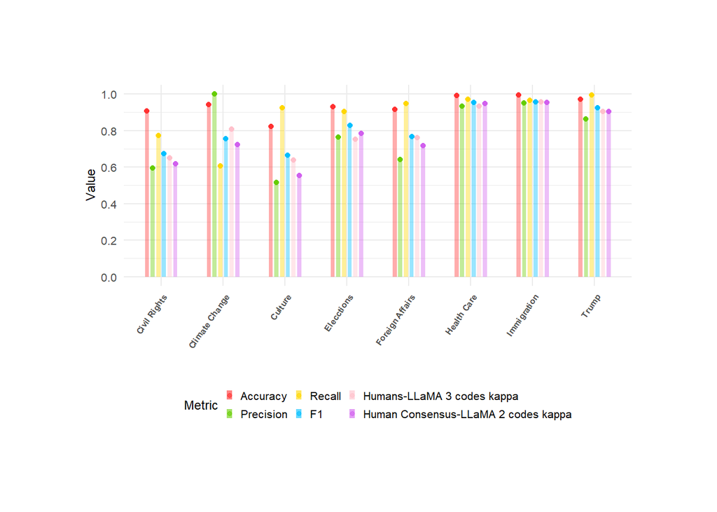

```r
plot_view <- ggplot(results_long,
                    aes(topic_names, Value, fill = Metric)) +

  # Large but balanced bars
  geom_col(position = position_dodge(width = 0.55),
           width = 0.4,        # wide bars, but not too wide
           alpha = 0.4) +      # lighter fill for clarity

  # Small points for clarity
  geom_point(aes(colour = Metric),
             position = position_dodge(width = 0.55),
             size = 1.5) +

  # Manual color scales
  scale_fill_manual(values = colors_LLaMA) +
  scale_colour_manual(values = colors_LLaMA) +

  # Y-axis limits and breaks
  scale_y_continuous(limits = c(0, 1),
                     breaks = seq(0, 1, 0.2)) +

  # Axis labels
  labs(x = "",
       y = "Value",
       fill = "Metric",
       colour = "Metric") +

  # Prevent clipping of long labels
  coord_cartesian(clip = "off") +

  # Compact legend (single guide)
  guides(
    fill = guide_legend(
      override.aes = list(size = 1.2, alpha = 0.6),
      ncol = 3
    )
  ) +

  # Theme adjustments for RStudio visibility
  theme_minimal() +
  theme(
    legend.position = "bottom",
    legend.box = "horizontal",
    legend.key.size = unit(0.3, "lines"),
    legend.spacing.x = unit(0.15, "lines"),

    # General text size
    text = element_text(size = 9),

    # X-axis labels
    axis.text.x = element_text(size = 6, angle = 55, hjust = 1, face = "bold", margin = margin(t = 2)),

    # Y-axis labels
    axis.text.y = element_text(size = 8),

    # Axis titles
    axis.title = element_text(size = 9),

    # Legend text
    legend.title = element_text(size = 9),
    legend.text  = element_text(size = 8),

    # Panel margins (balanced)
    plot.margin = margin(60, 60, 60, 60)
  )
print(plot_view)
```

## Correlations analysis for LLM

```r
# Generate names with structure hypothesis/topics
column_names <- as.vector(outer(labels, hypothesis, paste, sep = "_"))
# Rename variables to automatically calculate correlation matrices
colnames(LLM)[3:34] <- column_names

# List to store the correlation matrices
correlation_matrices <- list()

# Iterate over the topics
for (topic in labels) {
  # Select the columns for the topic with the different hypotheses
  columns_to_select <- paste(topic, hypothesis, sep = "_")
  selected_columns <- LLM[, columns_to_select]

  # Calculate the correlation matrix
  cor_matrix <- cor(selected_columns, use = "complete.obs")
  # Use "complete.obs" to omit NA values if needed

  # Store the correlation matrix in the list
  correlation_matrices[[topic]] <- cor_matrix
}

# View the correlation matrix for a specific topic, for example, "Immigration"
print(correlation_matrices[["Immigration"]])
```

```
##               Immigration_1
## Immigration_1             1
```

```r
corr_foraff = correlation_matrices[["ForAff"]]
corr_culture = correlation_matrices[["Culture"]]
corr_immigration = correlation_matrices[["Immigration"]]
corr_trump = correlation_matrices[["Trump"]]
corr_health = correlation_matrices[["HealthCare"]]
corr_elections = correlation_matrices[["Elections"]]
corr_civ_rights= correlation_matrices[["CivRights"]]
corr_EnvEnCli = correlation_matrices[["EnvEnCli"]]
```

Use the following line to save each correlation matrix as an XLSX file. ´write_xlsx(corr_foraff, “Results/Pilot/Correlations/corr_foraff”)´.

## Comparison: BART vs LLaMA, Pilot analysis. Appendix B, Figure 1.

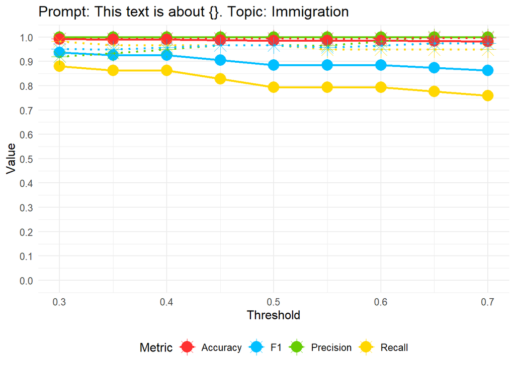

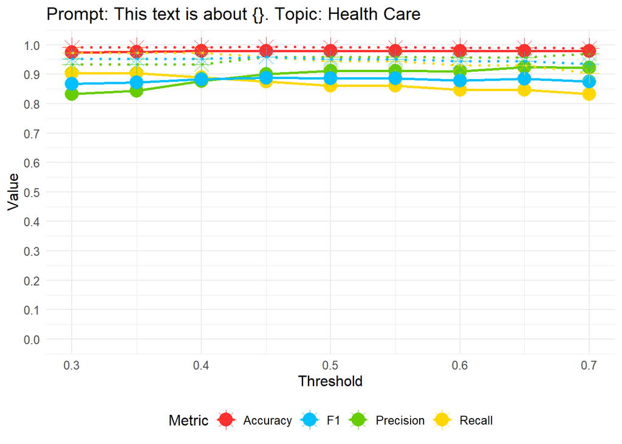

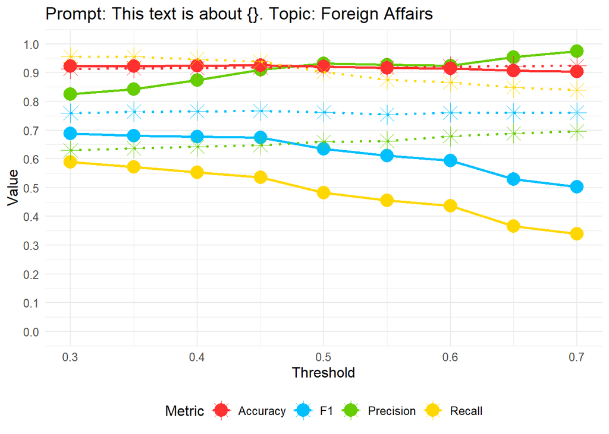

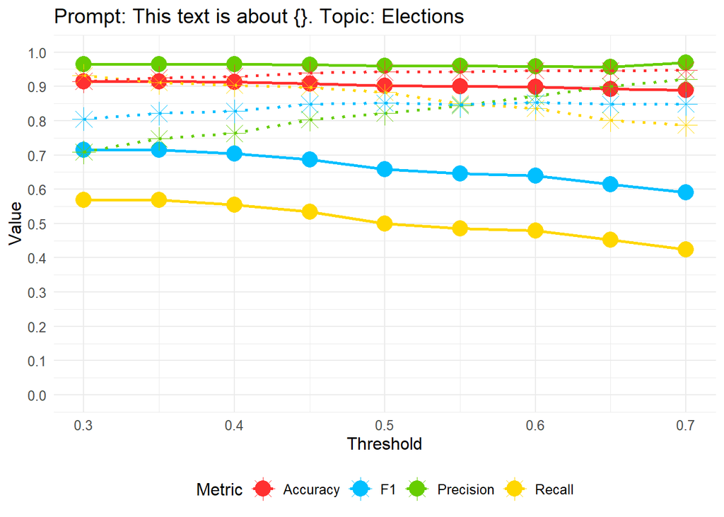

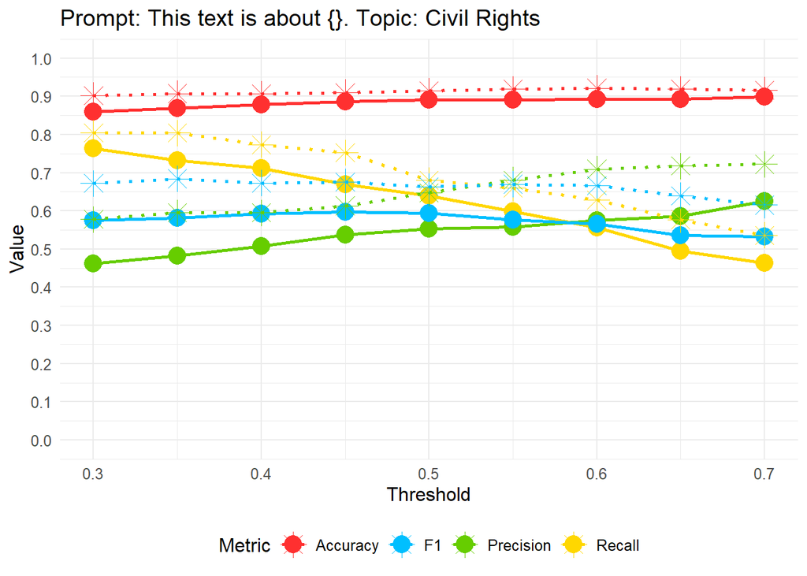

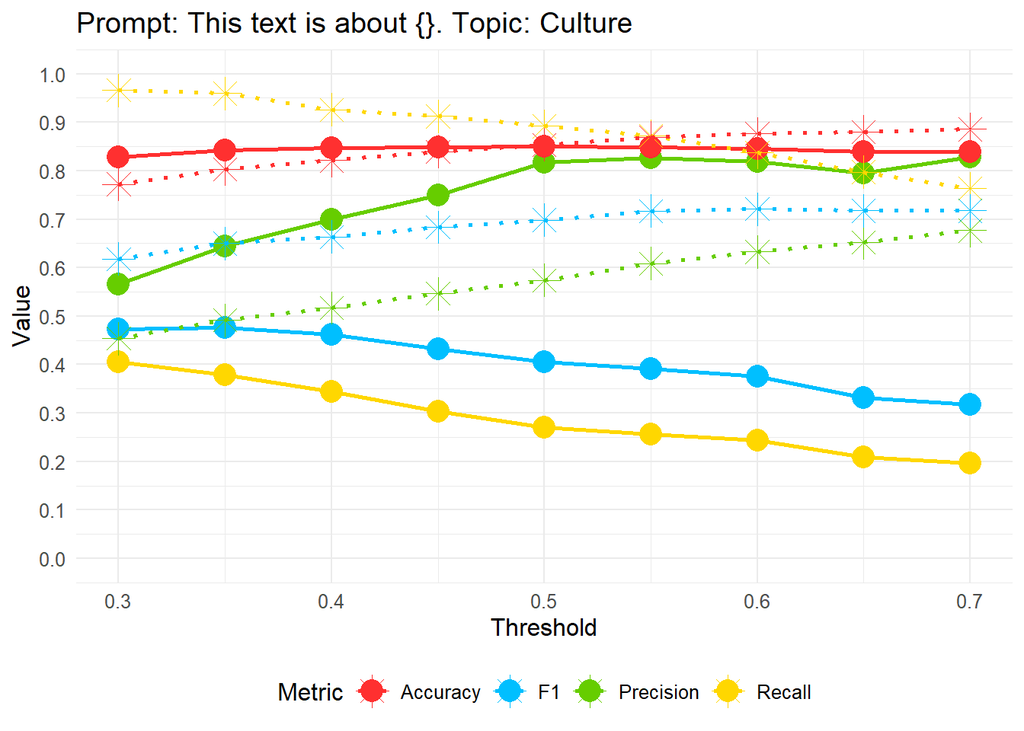

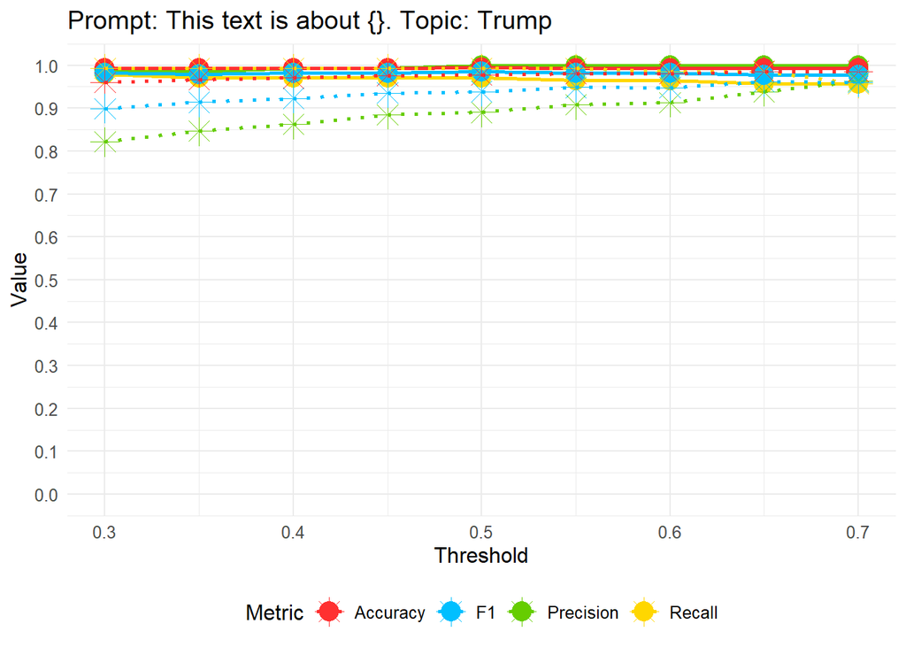

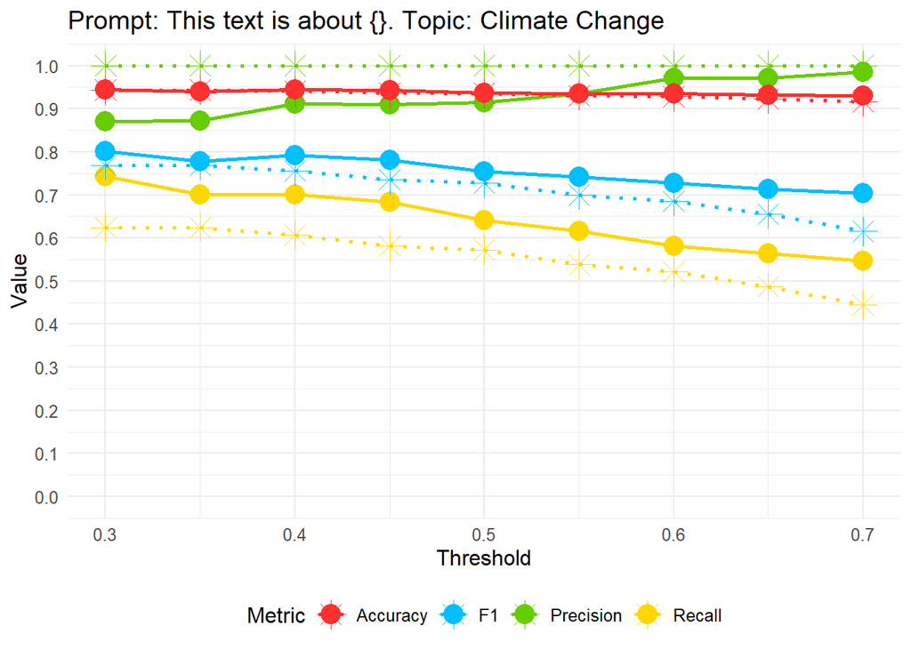

```r
# Iterate over each unique topic
for (i in 1:nrow(unique_combinations_LLaMA)) {

  top <- unique_combinations_LLaMA$topic[i]
  # Filter LLM data: ONLY hypothesis = 1
  subset_LLM <- results_pilot_LLM[
    results_pilot_LLM$hypothesis == 1 &
    results_pilot_LLM$topic == top,
  ]

  # Filter LLaMA data
  subset_LLaMA <- results_pilot_LLaMA[
    results_pilot_LLaMA$hypothesis == 1 &
    results_pilot_LLaMA$topic == top,
  ]
  plot <- ggplot() +

    # =========================
    # LLM: solid lines + circles
    # =========================
    geom_line(
      data = subset_LLM,
      aes(x = TH, y = recall, color = "Recall"),
      linewidth = 1
    ) +
    geom_point(
      data = subset_LLM,
      aes(x = TH, y = recall, color = "Recall"),
      shape = 16,
      size = 5
    ) +

    geom_line(
      data = subset_LLM,
      aes(x = TH, y = precision, color = "Precision"),
      linewidth = 1
    ) +
    geom_point(
      data = subset_LLM,
      aes(x = TH, y = precision, color = "Precision"),
      shape = 16,
      size = 5
    ) +

    geom_line(
      data = subset_LLM,
      aes(x = TH, y = accuracy, color = "Accuracy"),
      linewidth = 1
    ) +
    geom_point(
      data = subset_LLM,
      aes(x = TH, y = accuracy, color = "Accuracy"),
      shape = 16,
      size = 5
    ) +

    geom_line(
      data = subset_LLM,
      aes(x = TH, y = f1, color = "F1"),
      linewidth = 1
    ) +
    geom_point(
      data = subset_LLM,
      aes(x = TH, y = f1, color = "F1"),
      shape = 16,
      size = 5
    ) +

    # ============================
    # LLaMA: dotted lines + stars
    # ============================
    geom_line(
      data = subset_LLaMA,
      aes(x = TH, y = recall, color = "Recall"),
      linewidth = 1,
      linetype = "dotted"
    ) +
    geom_point(
      data = subset_LLaMA,
      aes(x = TH, y = recall, color = "Recall"),
      shape = 8,
      size = 5
    ) +

    geom_line(
      data = subset_LLaMA,
      aes(x = TH, y = precision, color = "Precision"),
      linewidth = 1,
      linetype = "dotted"
    ) +
    geom_point(
      data = subset_LLaMA,
      aes(x = TH, y = precision, color = "Precision"),
      shape = 8,
      size = 5
    ) +

    geom_line(
      data = subset_LLaMA,
      aes(x = TH, y = accuracy, color = "Accuracy"),
      linewidth = 1,
      linetype = "dotted"
    ) +
    geom_point(
      data = subset_LLaMA,
      aes(x = TH, y = accuracy, color = "Accuracy"),
      shape = 8,
      size = 5
    ) +

    geom_line(
      data = subset_LLaMA,
      aes(x = TH, y = f1, color = "F1"),
      linewidth = 1,
      linetype = "dotted"
    ) +
    geom_point(
      data = subset_LLaMA,
      aes(x = TH, y = f1, color = "F1"),
      shape = 8,
      size = 5
    ) +

    # =========================
    # General settings
    # =========================
    scale_color_manual(values = colors) +
    scale_y_continuous(
      limits = c(0, 1),
      breaks = seq(0, 1, by = 0.1)
    ) +

    labs(
      title = paste(
        "Prompt:",
        hypothesis_LLM[as.numeric(unique_combinations_LLM$hyp[i])],
        "Topic:",
        labels_LLM[as.numeric(unique_combinations_LLM$top[i])]
      ),
      x = "Threshold",
      y = "Value",
      color = "Metric"
    ) +

    theme_minimal() +
    theme(
      panel.background = element_rect(fill = "white", color = NA),
      legend.position = "bottom",
      text = element_text(size = 12)
    )

  filename <- sprintf("Results/Pilot/Comparison/%s_%s_Evolution_of_metrics_comparison.png", hyp, top)
    ggsave(filename = filename, plot = plot, dpi = 300, width = 10, height = 6, bg = "white")
  print(plot)
}
```

# Main Study

Data for the main study are posts from the official X (Twitter) accounts of US Members of Congress and from a set of political influencers in the US. A list of all Member accounts is generated and added to this the accounts of fifty top political influencers identified by the advertising firm Amra & Elma. An initial random sample of 70,546 posts was obtained for the combined list of accounts covering the period from January 1 to June 30, 2024, using the Brandwatch archive (see Appendix for more information about the accounts). This was then scaled down to a dataset manageable for human coders by drawing a random subsample of 4,500 posts for the main dataset. Results of the pilot analysis encourage the consideration of the prompt *h1:* “This text is about []”. An expanded set of eighteen issues, labeled as *l1 - l18*, is considered: *Conspiratorial Logic*, *The Economy in General*, *Donald Trump*, *Joe Biden*, *Democrats*, *Republicans*, *MAGA*, *Jews and Antisemitism in the US*, *Healthcare*, *Reproductive Rights*, *Homelessness*, *Immigration*, *Climate Change*, *Electric Vehicles*, *Elections*, *January 6 Insurrection*, *Race Relations*, *Resistance to Social Change or Traditional Values*.

This project involved the work of three human coders, who were tasked with classifying the posts as 0/1 for the issues considered. A sampling scheme was implemented to ensure that each post and each issue received two independent human codes, from coders A and B. The PIs of teh project have reviewed and adjudicated the disagreements between coders. As a result, for each issue, there is a consensus truth variable and two independent human codings.

If one prefers to work interactively with an R script, all the information and processes developed in this file regarding the Pilot analysis can be reproduced in the script `MainStudy.R`.

## Load the dataset

The input file containing the pilot dataset is *Main_Data.xlsx*, located in the *Data* folder.

```r
main_data <- read_excel("Data/Main_Data.xlsx",sheet='Final')
#head(main_data) #Uncomment to view the data header.
```

Initially, *main_data* has 4500 observations and 56 variables: each text is assigned an ID, along with the sentence itself, and for each of the 18 topics, three classification columns: one ending in *Truth*, which represents the consensus between code A and code B, one ending in *CodeA*, and another ending in *CodeB*.

For example, for economy we have *EconTruth*, *EconCodeA* and *EconCodeB*.

In this main project, as these are real texts obtained from a social network, the writing is quite imprecise and irregular. Although BART performs very well with this type of writing, we briefly standardize the texts to be classified by converting everything to lowercase, cleaning up contractions, and removing emojis. We keep retweets, hashtags, and user mentions. If user mentions or hashtags should also be removed, it is enough to uncomment the corresponding line in the clean_text function.

```r
clean_text <- function(text) {
  # Convert to uppercase: consistency, pattern recognition and reduction of complexity
  text <- tolower(text)
  # Remove encoding artifacts (UTF-8 misinterpreted issues)
  text <- iconv(text, from = "UTF-8", to = "ASCII//TRANSLIT", sub = "")
  text <- stri_replace_all_regex(text, "[\\p{So}\\p{Cn}]", "")  # Elimina símbolos y caracteres desconocidos
  text <- str_replace_all(text, "\\b(i'm)\\b", "i am")
  text <- str_replace_all(text, "\\b(you're)\\b", "you are")
  text <- str_replace_all(text, "\\b(he's)\\b", "he is")
  text <- str_replace_all(text, "\\b(she's)\\b", "she is")
  text <- str_replace_all(text, "\\b(it's)\\b", "it is")
  text <- str_replace_all(text, "\\b(we're)\\b", "we are")
  text <- str_replace_all(text, "\\b(they're)\\b", "they are")
  #text <- str_replace_all(text, "[^\x01-\x7F]", "")
  # text <- str_replace_all(text, "[\\p{So}\\p{Cn}]", "")
  # Replace contractions for the verb 'to have'
  text <- str_replace_all(text, "\\b(i've)\\b", "i have")
  text <- str_replace_all(text, "\\b(you've)\\b", "you have")
  text <- str_replace_all(text, "\\b(he's)\\b", "he has")
  text <- str_replace_all(text, "\\b(she's)\\b", "she has")
  text <- str_replace_all(text, "\\b(it's)\\b", "it has")
  text <- str_replace_all(text, "\\b(we've)\\b", "we have")
  text <- str_replace_all(text, "\\b(they've)\\b", "they have")
  # Remove user mentions
  #text <- str_remove(text, "^rt\\s+@\\S+\\s*")
  #text <- str_remove_all(text, "@\\S+")
  # Remove hashtags
  #text <- str_remove_all(text, "#\\S+")
  # Remove URLs
  text <- str_remove_all(text, "http\\S+|www\\S+")
  # New line to remove everything after 'HTTP' until a space
  text <- str_remove_all(text, "HTTP\\S*") # Removes everything from 'https:' until the first space
  # Remove problematic characters (single quotes, double quotes, apostrophes, etc.)
  text <- str_remove_all(text, "[\"'`´^¨]")
  # Remove non-alphanumeric characters, except spaces
  #    text <- str_remove_all(text, "[^\\w\\s]")
  # Remove non-alphanumeric characters **EXCEPT @ and #**
  text <- str_replace_all(text, "[^\\w\\s@#]", "")
  # Remove extra spaces
  text <- str_squish(text)

  return(text)
}
```

Apply ´clean_text´ function to the ´sequence´ variable in ´main_data´. The newly created variable with the debugged text is named ´clean_text´.

```r
main_data$clean_text <- clean_text(main_data$sequence)
if (anyNA(main_data$sequence)) {
  warning("The 'sequence' column contains missing values (NA). It is recommended to handle these values before proceeding.")
  # Optional: Remove rows with missing values
  main_data <- main_data[!is.na(main_data$sequence), ]
}

main_data$clean_text <- ifelse(main_data$clean_text == "", "empty sentence", main_data$clean_text)
# Uncomment to save as xlsx
#write_xlsx(main_data, "Data/Main_Data.xlsx")
```

## Classification process with BART

The first step is to obtain the classifications for each text in the main project dataset, considering the hypothesis *h1*: “This text is about []”, and the eighteen previously defined issues (*l1–l18*).

To do so, we apply the `textZeroShot` function of the `text` library combined with a loop to consider *h1* and all the issues, labeled as *l1-l18*, applied over the ´clean_text´ variable obtained after posts debugg (see Section *Main project/Load the dataset*).

After the classification process, *main_data* will contain 75 variables: the initial 57, plus 18 classifications for each *hi_lj* combination (referring to the *i*-th prompt and the *j*-th topic)

```r
labels= c("Conspiratorial Logic", "The Economy in General","Donald Trump","Joe Biden","Democrats","Republicans","MAGA","Jews and Antisemitism in the US","Healthcare","Reproductive Rights","Homelessness","Immigration","Climate Change","Electric Vehicles","Elections","January 6 Insurrection","Race Relations","Resistance to Social Change or Traditional Values")
hypothesis=c("This text is about {}.")
```

To run the classification process using BART, apply the `ZSC_main` function included in `MainStudy.R`. This function requires the following input parameters: ([bart function - Bayesian Additive Regression Trees - RDocumentation](https://www.rdocumentation.org/packages/dbarts/versions/0.9-30/topics/bart?utm_source=chatgpt.com))

- `main_data`: a dataframe containing the 4500 texts to be classified.
- `labels`: a vector comprising the 18 issues to be considered.
- `hypothesis`: a vector encompassing the working prompt.

The classification results are appended to the `main_data` dataframe, resulting in 18 new columns corresponding to each *hi_lj* combination, where *hi* denotes the hypothesis/prompt *i* and *lj* represents the label *j*.

This approach facilitates zero-shot classification using the BART model, enabling the evaluation of the relationship between texts and formulated hypotheses without additional training.

This part of the process is provided in scripts separate from the rest of the analysis, as the execution time is high and may slow down or cause memory issues during the compilation of the Markdown document.

It is recommended not to apply the classification procedure to all posts and all issues at once, as this may cause performance issues. The preferred approach is to partition the dataset by rows. The script provides an example of this application, using the first 200 posts and the 18 issues: ´main_data_1_200 <- ZSC_main(main_data[1:200, ], labels, hypothesis)´.

## Analysis of the metrics. BART Classification

The input for this section is the `main_data` dataframe created in the previous section *Main analysis/Classification process*. Excel file *Main_classification.xlsx*, sheet *BART*, located in the *Data* folder can be used instead.

```r
excel_file <- "Data/Main_classification.xlsx"
LLM <- read_excel(excel_file, sheet="BART")%>%
  select(ID,sequence, h1_l1, h1_l2, h1_l3, h1_l4, h1_l5, h1_l6, h1_l7, h1_l8, h1_l9, h1_l10, h1_l11, h1_l12, h1_l13, h1_l14, h1_l15, h1_l16, h1_l17, h1_l18)

human <- read_excel(excel_file)%>%
  select(ID,sequence, ConsTruth, ConsCodeA, ConsCodeB, EconTruth, EconCodeA, EconCodeB, TrumpTruth, TrumpCodeA, TrumpCodeB, BidenTruth, BidenCodeA, BidenCodeB, DemsTruth, DemsCodeA, DemcCodeB, GOPTruth, GOPCodeA, GOPCodeB, MAGATruth, MAGACodeA, MAGACodeB, JewsTruth, JewsCodeA, JewsCodeB, HealthTruth, HealthCodeA, HealthCodeB, ReproTruth, ReproCodeA, ReproCodeB, HomelessTruth, HomelessCodeA, HomeLessCodeB, ImmTruth, ImmCodeA, ImmCodeB, ClimateTruth, ClimateCodeA, ClimateCodeB, ElecVTruth, ElecVCodeA, ElecVCodeB, ElectionsTruth, ElectionsCodeA, ElectionsCodeB, Jan6Truth, Jan6CodeA, Jan6CodeB, RaceTruth, RaceCodeA, RaceCodeB, SocChgTruth, SocChgCodeA, SocChgCodeB)
```

BART scores have to be binarized in order to compare them agains human classifications. A grid of binarization thresholds between 0.3 and 0.7 was employed to assess the impact of different threshold values on the comparison metrics.

```r
thresholds <- c(0.3, 0.35, 0.4, 0.45, 0.5, 0.55, 0.6, 0.65, 0.7)

# Function to apply threshold
apply_threshold <- function(value, threshold) {
  ifelse(value >= threshold, 1, 0)
}
# Columns to apply the threshold. It considers only the relevant columns that include classifications.
classifications <- setdiff(colnames(LLM), c("ID", "sequence"))
# Initialize a list to store the DataFrames
threshold_dataframes <- list()
for (threshold in thresholds) {
  # Generate DataFrame name dynamically (ensure integer conversion)
  df_name <- sprintf("LLM_%02d", as.integer(threshold * 100))

  # Create a copy of the DataFrame and apply the threshold
  LLM_copy <- LLM
  LLM_copy[classifications] <- lapply(LLM_copy[classifications], apply_threshold, threshold)
  LLM_copy$TH <- threshold

  # Store in the list
  threshold_dataframes[[df_name]] <- LLM_copy
}
# Uncomment following lines to save different binarizations as Excel
# wb <- createWorkbook()
# for (name in names(threshold_dataframes)) {
# addWorksheet(wb, name)
# writeData(wb, name, threshold_dataframes[[name]])}
# saveWorkbook(wb, "Data/main_binarizations_BART.xlsx", overwrite = TRUE)
```

Next, we organize the variables in order to proceed with the comparison between the binarized BART classifications and those provided by the human coders.

```r
# Make a copy of 'human' without 'ID' and 'TEXT'
human_copy <- human %>% select(matches("Truth$"))
human_all <- human %>% select(-"ID", -"sequence")

cols_data1 <- setdiff(names(LLM_copy), c("ID", "sequence", "clean_text", "TH"))
```

Create an empty results DataFrame where we store, for each threshold and each issue, different goodness-of-fit metrics: False Positives (*FP*), False Negatives (*FN*), True Positives (*TP*), True Negatives (*TN*), threshold value (*TH*), *recall*, *precision*, *accuracy*, *f1*, Cohen’s Kappa between human consensus and BART (*kappa*), Fleiss’s kappa between human Code 1, Code 2 and BART (*kappa_fleiss*), Cohen’s Kappa between human Code 1 and Code 2 (*kappa_C1C2*), Cohen’s Kappa between human Code 1 and BART (*kappa_C1BART*), Cohen’s Kappa between human Code 2 and BART (*kappa_C2BART*).

For the calculation of recall, precision, accuracy, and F1, the consensus value of the human coders is considered as the ground truth.

```r
results_df <- data.frame(Issue=character(), FP=integer(), FN=integer(), TP=integer(), TN=integer(), TH=numeric(), recall=numeric(), precision=numeric(), accuracy=numeric(), f1 = numeric(),kappa=numeric(), kappa_fleiss=numeric(), kappa_C1C2=numeric(),kappa_C1BART=numeric(), kappa_C2BART=numeric(), stringsAsFactors = FALSE)
```

Next, through the use of loops, all possible binarizations are iterated over, and the previously defined metrics are computed accordingly.

```r
for(df_name in names(threshold_dataframes)){
  LLM_copy <- threshold_dataframes[[df_name]]
  TH <- unique(LLM_copy$TH)
  for (k in 1:18) {  # 18 labels/topics per hypothesis
    # Define true/predicted labels
    y_true <- human_copy[k]
    y_pred <- LLM_copy[[cols_data1[k]]]
    selected_columns <- human_all[, c(3*k-1, 3*k)]
    selected_columns <- cbind(y_pred, selected_columns)

    #first column in selected_columns is BART classification
    #second column in selected_columns is Coder1 classification
    #third column in selected_columns is Coder2 classification
    # Compute confusion matrix
    cm <- table(unlist(y_true), y_pred)
    FP <- cm[1,2]
    FN <- cm[2,1]
    TP <- cm[2,2]
    TN <- cm[1,1]
    # Compute classification metrics
    precision <- ifelse((TP + FP) != 0, TP / (TP + FP), 0)
    recall <- ifelse((TP + FN) != 0, TP / (TP + FN), 0)
    accuracy <- ifelse((TP + TN + FP + FN) != 0, (TP + TN) / (TP + TN + FP + FN), 0)
    f1_score <- ifelse((precision + recall) != 0, (2 * precision * recall) / (precision + recall), 0)
    # Compute Cohen's Kappa
    kappa_stat <- kappa2(data.frame(y_true, y_pred))$value
    kappa_C1C2 <- kappa2(data.frame(selected_columns[,2], selected_columns[,3]))$value
    kappa_C1BART <- kappa2(data.frame(selected_columns[,2], y_pred))$value
    kappa_C2BART <- kappa2(data.frame(selected_columns[,3], y_pred))$value
    kappa_fleiss=kappam.fleiss(as.matrix(selected_columns))$value
    # Create a new row with the results
    new_row <- data.frame(
      Issue = labels[k], FP = FP, FN = FN, TP = TP, TN = TN,TH=TH,
      recall = recall, precision = precision, accuracy = accuracy,
      f1 = f1_score, kappa=kappa_stat,
      kappa_fleiss=kappa_fleiss,kappa_C1C2=kappa_C1C2,
      kappa_C1BART=kappa_C1BART,kappa_C2BART=kappa_C2BART
    )

    # Append new row to results DataFrame
    results_df <- bind_rows(results_df, new_row)
    # Define class labels
    classes <- c("Class 0", "Class 1")

  }}

# Uncomment to save ´results_df´as a XLSX file.
 write_xlsx(results_df, "Results/Main project/BART/results_main_BART.xlsx")
results_main_BART = results_df
```

Once all the metrics are calculated, they are represented in different contexts to facilitate their analysis and enable a decision to be made regarding the threshold.

```r
colors <- c("Recall" = "#FFD700", "Precision" = "#66CD00", "Accuracy" = "#FF3030", "F1" = "#00BFFF", "Human Consensus-BART 2 codes kappa"="#D15FEE", "Humans-BART 3 codes kappa"="#FFC0CB", "Code 1-Code 2 kappa"="#C1CDC1", "Code 1-BART kappa"="#8B0000", "Code 2-BART kappa"="#27408B")

unique_combinations <- unique(results_df$Issue)
```